# Amazon ML Engineer Hiring Challenge

Hariprasath Venkatraman

#### Import Necessary Packages

```r
{
  library(tidyverse) # for data manipulation and plot
  library(psych) # to describe a column
  library(DT) # to show data in table format
  library(ggpubr) #summary plot
  library(randomForest) # for random forest model
  library(missRanger) #for imputing a missing value
  library(caret) # to generate stratified sample from train data
  library(patchwork) # to arrange the chart
  library(ggcorrplot) # for correlation plot

}
```

#### Import Train and Test Dataset

```r
train <- read.csv("train.csv",header = T, na.strings = c(""," ","NA"))

test <- read.csv("test.csv",header = T, na.strings = c(""," ","NA"))
```

#### Let's analyze the structure of the train and test dataset

### Train Dataset

```r
str(train)
```

```
## 'data.frame':    10738 obs. of  12 variables:
##  $ customer_id                     : chr  "csid_1" "csid_2" "csid_3" "csid_4" ...
##  $ customer_visit_score            : num  13.2 17.1 17.5 31.4 11.9 ...
##  $ customer_product_search_score   : num  9.45 7.33 5.14 4.92 4.24 ...
##  $ customer_ctr_score              : num  -0.0702 0.1533 0.1067 -0.0202 0.1872 ...
##  $ customer_stay_score             : num  -0.14 -0.103 0.263 -0.101 0.173 ...
##  $ customer_frequency_score        : num  0.437 0.38 0.418 0.778 0.162 ...
##  $ customer_product_variation_score: num  4.71 4.21 4.48 5.06 3.45 ...
##  $ customer_order_score            : num  2.54 4.19 3.88 2.71 3.68 ...
##  $ customer_affinity_score         : num  7.96 17.52 12.6 4.8 56.64 ...
##  $ customer_active_segment         : chr  "C" "C" "C" "AA" ...
##  $ X1                              : chr  "F" "A" "BA" "F" ...
##  $ customer_category               : int  0 0 0 0 0 0 0 0 0 0 ...
```

### Test Dataset

```r
str(test)
```

```
## 'data.frame':    7160 obs. of  11 variables:
##  $ customer_id                     : chr  "csid_10739" "csid_10740" "csid_10741" "csid_10742" ...
##  $ customer_visit_score            : num  22.5 13.2 14.6 26.1 19.8 ...
##  $ customer_product_search_score   : num  3.7 3.6 5.08 3.03 5.02 ...
##  $ customer_ctr_score              : num  0.11881 0.13099 -0.00465 0.22974 -0.01135 ...
##  $ customer_stay_score             : num  0.0933 0.0536 -0.0363 0.2046 -0.0288 ...
##  $ customer_frequency_score        : num  0.689 0.143 0.334 3.768 0.287 ...
##  $ customer_product_variation_score: num  5.79 3.94 4.25 6.94 4.59 ...
##  $ customer_order_score            : num  3.75 3.47 3.86 2.36 3.28 ...
##  $ customer_affinity_score         : num  7.662 34 33.486 0.795 15.052 ...
##  $ customer_active_segment         : chr  "B" "B" "B" "B" ...
##  $ X1                              : chr  "BA" "AA" "AA" "BA" ...
```

#### Let's analyze the summary of each numerical variable in the train and test dataset

### Train Dataset

```r
datatable(
  describe(train[,c(2:9)], IQR = T),
  extensions = 'FixedColumns',
  options = list(
  dom = 't',
  scrollX = TRUE,
  fixedColumns = TRUE
  )
  )
```

|  | vars | n | mean | sd | median | trimmed | mad | min | max | range | skew | kurtosis | se | IQR |
| --- | --- | --- | --- | --- | --- | --- | --- | --- | --- | --- | --- | --- | --- | --- |
| customer_visit_score | 1 | 10738 | 19.0609412947336 | 7.41960907621886 | 18.7741092114571 | 18.9800922786764 | 8.06526615958632 | 0.56896476668951 | 47.3066909826768 | 46.7377262159873 | 0.101419451555782 | -0.407373826613344 | 0.071601038935706 | 10.9836980527995 |
| customer_product_search_score | 2 | 10696 | 5.27484715286252 | 1.88255858595092 | 5.21847928619827 | 5.2432756975225 | 1.89225632205038 | -0.161939981831988 | 16.6382432951636 | 16.8001832769956 | 0.289190517952606 | 0.543684847316363 | 0.018202783485526 | 2.54877669608221 |
| customer_ctr_score | 3 | 10738 | 0.175911980601167 | 0.372828938271964 | 0.0740781362737432 | 0.0884752054244665 | 0.105333242849581 | -0.547989083794633 | 2.67947424214472 | 3.22746332593936 | 3.21512260727107 | 10.9520719447817 | 0.00359789027310492 | 0.148766423334261 |
| customer_stay_score | 4 | 10701 | 0.374230061847208 | 1.22203079845813 | 0.0372007949595798 | 0.0839329651337038 | 0.122678685900043 | -0.462494063925482 | 14.7019141712982 | 15.1644082352237 | 5.00732220985001 | 29.7747169402828 | 0.0118132656272096 | 0.206694498645528 |
| customer_frequency_score | 5 | 10738 | 2.37689468789176 | 5.60191093436555 | 0.516829935879115 | 0.880353922767123 | 0.387722034172206 | 0.0285752105100202 | 52.3950139225105 | 52.3664387120005 | 4.0818722337169 | 19.1808041235317 | 0.0540598081119218 | 0.811769860237143 |
| customer_product_variation_score | 6 | 10692 | 5.78817952863934 | 2.53130945752653 | 4.84257459475173 | 5.29459399613512 | 1.22479520654559 | 2.75283614762163 | 18.7438357201997 | 15.9909995725781 | 1.85112743880598 | 3.18866204047182 | 0.0244802453813726 | 2.09316585450588 |
| customer_order_score | 7 | 10672 | 3.15007053855663 | 1.03541550966791 | 3.11839417157827 | 3.10967141534182 | 0.967860975966943 | 0.36333795012621 | 9.09020550869893 | 8.72686755857272 | 0.576702745360992 | 1.20882313252208 | 0.0100228621609676 | 1.30254901228843 |
| customer_affinity_score | 8 | 10738 | 17.0618357856372 | 18.7626933621217 | 12.6533570715631 | 13.9518747077297 | 13.3250282380325 | -0.48683405628271 | 248.552754701611 | 249.039588757893 | 2.99264756499457 | 16.8454456581112 | 0.181064571483411 | 18.5844912863917 |

### Test Dataset

```r
datatable(
  describe(test[,c(2:9)] , IQR = T),
  extensions = 'FixedColumns',
  options = list(
  dom = 't',
  scrollX = TRUE,
  fixedColumns = TRUE
  )
  )
```

|  | vars | n | mean | sd | median | trimmed | mad | min | max | range | skew | kurtosis | se | IQR |
| --- | --- | --- | --- | --- | --- | --- | --- | --- | --- | --- | --- | --- | --- | --- |
| customer_visit_score | 1 | 7160 | 19.7003847498194 | 6.98093229918197 | 19.2560505545986 | 19.5035591298813 | 7.7435221533191 | 1.2483854812119 | 42.9605000314237 | 41.7121145502118 | 0.202293363750895 | -0.409644934707935 | 0.0825005635377418 | 10.5065996297268 |
| customer_product_search_score | 2 | 7131 | 5.38597002665557 | 1.77985024715318 | 5.35810367739366 | 5.36316843804269 | 1.80182501047841 | -0.113790502197931 | 13.6781080588034 | 13.7918985610014 | 0.17724067627288 | 0.160002957038059 | 0.0210769732820751 | 2.43298386433949 |
| customer_ctr_score | 3 | 7160 | 0.111038082563603 | 0.260733252321648 | 0.0631776098571011 | 0.0698742648843121 | 0.0948018900147172 | -0.615133999127201 | 2.52858352522617 | 3.14371752435338 | 4.6322026710776 | 26.5400701493709 | 0.00308134205113045 | 0.130040356320447 |
| customer_stay_score | 4 | 7144 | 0.202822040368598 | 0.886823570814811 | 0.0245077723691778 | 0.0494753731228282 | 0.105191890175989 | -0.381836119965604 | 13.5332331881836 | 13.9150693081492 | 7.69028648532326 | 70.8055192047247 | 0.0104921986546274 | 0.163468066055107 |
| customer_frequency_score | 5 | 7160 | 1.88558795923482 | 4.96721258702486 | 0.457635865937246 | 0.615136209319188 | 0.321340282507388 | 0.0229569563661802 | 49.6837387628728 | 49.6607818065066 | 4.6074972600732 | 23.9598089740138 | 0.0587024512025902 | 0.54063101557575 |
| customer_product_variation_score | 6 | 7117 | 5.44422636910175 | 2.33624355399858 | 4.6694330381664 | 4.9452029902509 | 1.02921187762913 | 2.71881896432232 | 19.0957992860003 | 16.376980321678 | 2.30915823043079 | 5.6508464371843 | 0.0276929762481968 | 1.56663642796596 |
| customer_order_score | 7 | 7119 | 3.30944009947606 | 1.06014412211678 | 3.25409569967822 | 3.26515520805181 | 0.912300649598239 | 0.620934572817478 | 11.3883053414277 | 10.7673707686102 | 0.744704126127013 | 2.2688779441703 | 0.0125647951742949 | 1.23039788002636 |
| customer_affinity_score | 8 | 7160 | 19.8890351341823 | 20.7836791186241 | 14.6304766824374 | 16.4344452517062 | 13.3525310467986 | -0.501215489603341 | 257.251810119939 | 257.753025609542 | 2.82061646060367 | 14.0559279714457 | 0.245621238853012 | 19.1927122386482 |

#### Let's view the sample data of train and test dataset.

### Train Dataset

```r
datatable(
  head(train),
  extensions = 'FixedColumns',
  options = list(
  dom = 't',
  scrollX = TRUE,
  fixedColumns = TRUE
  )
  )
```

|  | customer_id | customer_visit_score | customer_product_search_score | customer_ctr_score | customer_stay_score | customer_frequency_score | customer_product_variation_score | customer_order_score | customer_affinity_score | customer_active_segment | X1 | customer_category |
| --- | --- | --- | --- | --- | --- | --- | --- | --- | --- | --- | --- | --- |
| 1 | csid_1 | 13.1684249345829 | 9.44766169079582 | -0.0702026428938979 | -0.139540879286161 | 0.436956030816412 | 4.70576093921216 | 2.53798505186998 | 7.95950322137846 | C | F | 0 |
| 2 | csid_2 | 17.0929788029114 | 7.32905598898363 | 0.153298208323694 | -0.102726241437363 | 0.380340143695337 | 4.20513805253699 | 4.19344410230088 | 17.5173808344761 | C | A | 0 |
| 3 | csid_3 | 17.5053343318499 | 5.1436762479362 | 0.106709153109228 | 0.262833744381634 | 0.41764799390509 | 4.47906979102526 | 3.87897149571482 | 12.5951547632221 | C | BA | 0 |
| 4 | csid_4 | 31.4233811728797 | 4.91773969744339 | -0.0202260077687631 | -0.100525775321307 | 0.778129709336026 | 5.0555349760572 | 2.70893961396362 | 4.79507317683626 | AA | F | 0 |
| 5 | csid_5 | 11.9095017207591 | 4.23707309229071 | 0.187178303755347 | 0.172890821245402 | 0.162066539729601 | 3.44524683701291 | 3.67736013561661 | 56.6363258231566 | C | AA | 0 |
| 6 | csid_6 | 9.0079217312265 | 7.05156830564772 | 0.161564329650771 | 0.0409969438021328 | 0.191935099447075 | 4.20983978008737 | 3.18196113140493 | 18.8626795150842 | C | BA | 0 |

### Test Dataset

```r
datatable(
  head(test) ,
  extensions = 'FixedColumns',
  options = list(
  dom = 't',
  scrollX = TRUE,
  fixedColumns = TRUE
  ))
```

|  | customer_id | customer_visit_score | customer_product_search_score | customer_ctr_score | customer_stay_score | customer_frequency_score | customer_product_variation_score | customer_order_score | customer_affinity_score | customer_active_segment | X1 |
| --- | --- | --- | --- | --- | --- | --- | --- | --- | --- | --- | --- |
| 1 | csid_10739 | 22.500173960607 | 3.70214478456454 | 0.118811428891911 | 0.0932531401662105 | 0.689236507367001 | 5.78684166683451 | 3.74800881105096 | 7.661715524932 | B | BA |
| 2 | csid_10740 | 13.2259504345984 | 3.60010182944908 | 0.130985240533097 | 0.0535751712815929 | 0.142755665513572 | 3.94035938270587 | 3.46965907443205 | 33.9996787220073 | B | AA |
| 3 | csid_10741 | 14.6033757562269 | 5.08404727866954 | -0.00465086976637367 | -0.0362990987075682 | 0.333709058515231 | 4.25466205235749 | 3.85593897040824 | 33.4856303771876 | B | AA |
| 4 | csid_10742 | 26.1499048452367 | 3.02550064822768 | 0.22973950826033 | 0.204590996717486 | 3.76840462703654 | 6.94262523893689 | 2.36242061329996 | 0.795371793965439 | B | BA |
| 5 | csid_10743 | 19.8106299899986 | 5.0203995791478 | -0.0113472143483874 | -0.0287796526147681 | 0.286841127330858 | 4.5855128426351 | 3.27862412985879 | 15.0520583435717 | C | BA |
| 6 | csid_10744 | 31.8408175011556 | 5.69363016821498 | -0.0426643877124994 | -0.0270737333766293 | 0.310253077888213 | 4.0321817798525 | 2.98804213798681 | 12.0298940759026 | A | A |

### Exploratory Data Analysis

### Customer Category Variable(Target)

#### Let's check the dependent variable customer category distribution. The customer category variable in binary format(0,1) so for the visualization purpose change those variable levels into 0 as Group_0 and 1 as Group_1.

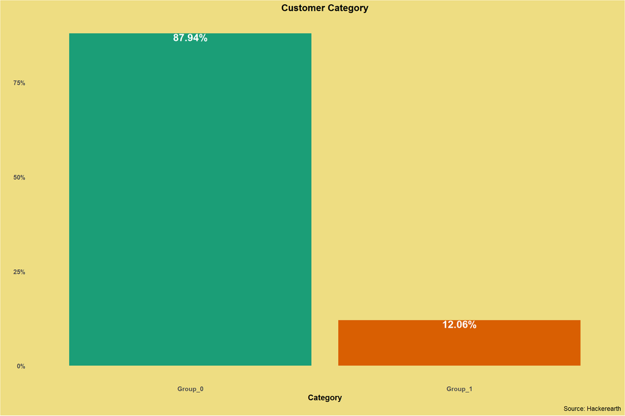

```r
train %>% mutate(customer_category =
                   recode(customer_category,
                          "0" = "Group_0",
                          "1" = "Group_1")) %>%
  group_by(customer_category) %>%
  summarise(counts = n()) %>%
  mutate(perc = counts/sum(counts)) %>%
  ungroup() %>%
  ggplot(aes(
    x = as.factor(customer_category),
    y = perc,
    label = scales::percent(perc,accuracy = .01),
    fill = as.factor(customer_category)
  )) +
  geom_bar(stat = "identity")+
  scale_fill_brewer(palette = "Dark2")+
  geom_text(hjust=0.5,vjust=1,color="white",
            fontface="bold",size=5 )+
  scale_y_continuous(labels = scales::percent )+
  labs(x="Category",
       y="",
       title = "Customer Category",
       caption = "Source: Hackerearth")+
  theme_dark()+
  theme(
    legend.position = "none",
    axis.text = element_text(face = "bold"),
    axis.title.x =  element_text(face = "bold"),
    axis.ticks = element_blank(),
    panel.grid = element_blank(),
    plot.background = element_rect(fill = "lightgoldenrod"),
    panel.background = element_rect(fill = "transparent"),
    plot.title =  element_text(face = "bold",hjust = 0.5)
  )
```

#### The above plot shows that the customer category biased to group_0 and clearly shows that highly imbalanced class. In the modeling part, the class imbalance issue will be handled in various techniques(data level, algorithmic level approach)

#### Let's's see the distribution of each numerical variable in the train and test dataset.

### Train Dataset

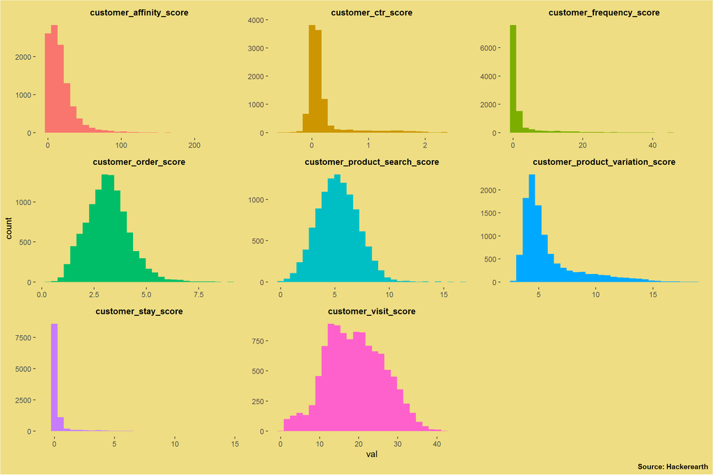

```r
train %>% gather("var","val",c(2:9)) %>%
  ggplot(aes(x=val,fill=var))+
  geom_histogram()+
  facet_wrap(~var,scales = "free")+
  labs(caption = "Source: Hackerearth")+
  theme(
    legend.position = "none",
    strip.background.x =   element_rect(fill = "transparent"),
    strip.text.x = element_text(color="black",size = 10,
                                face="bold"),
    panel.grid = element_blank(),
    plot.caption = element_text(face = "bold"),
    plot.background = element_rect(fill = "lightgoldenrod"),
    panel.background = element_rect(fill = "transparent")
  )
```

### Test Dataset

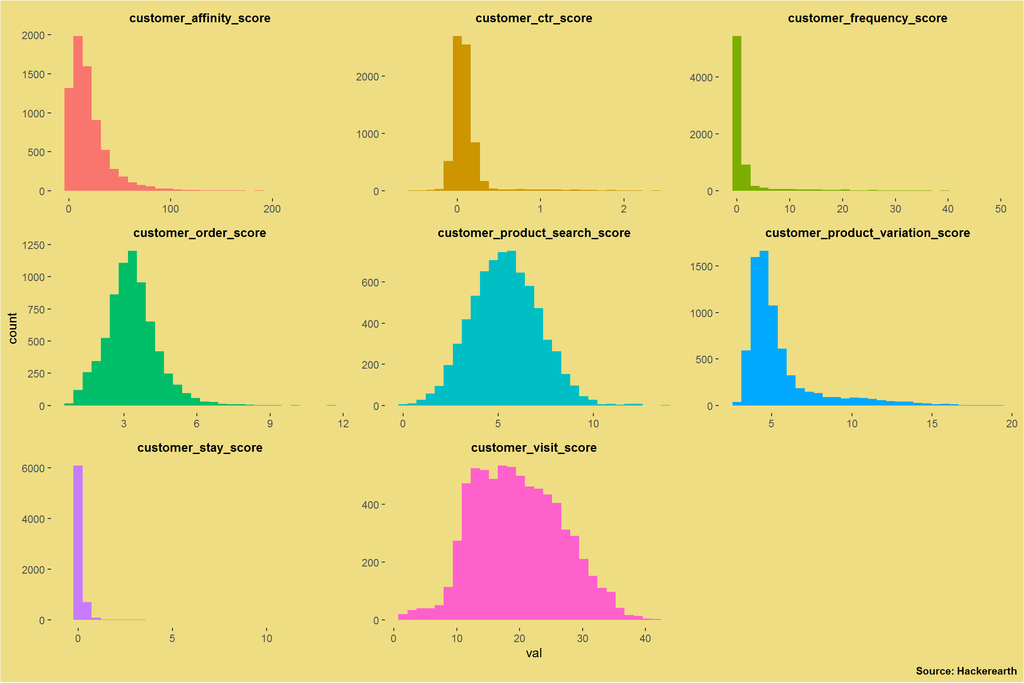

```r
test %>% gather("var","val",c(2:9)) %>%
  ggplot(aes(x=val,fill=var))+
  geom_histogram()+
  facet_wrap(~var,scales = "free")+
  labs(caption = "Source: Hackerearth")+
  theme(
    legend.position = "none",
    strip.background.x =   element_rect(fill = "transparent"),
    strip.text.x = element_text(color="black",size = 10,
                                face="bold"),
    panel.grid = element_blank(),
    plot.caption = element_text(face = "bold"),
    plot.background = element_rect(fill = "lightgoldenrod"),
    panel.background = element_rect(fill = "transparent")
  )
```

**Click the button to view the chart for each column**

### Customer Visit Score

#### Let's check the score based on the customer how regularly visits the website.

#### First, let's perform the Univariate analysis and see the customer visit score distribution.

#### For the visualization can use the histogram and boxplot. The histogram will say how the score has distributed that is whether it is normally distributed or skewed.

#### Boxplot will also explain the distribution with outlier points.

#### For the histogram the bins are selected by using Freedman–Diaconis rule.

#### Let's look a quick summary of the customer visit score

```r
summary(train$customer_visit_score)
```

```
##    Min. 1st Qu.  Median    Mean 3rd Qu.    Max.
##   0.569  13.518  18.774  19.061  24.502  47.307
```

#### The summary shows that there is no negative customer visit score and the mean is 19.061.

#### To get and show the boxplot statistics summary let's create a function to get the box plot summary.

```r
box_summary <- function(columns){

cal <- boxplot.stats(columns)$stats
return(cal)
}
```

#### binwidth selected by using Freedman–Diaconis rule.

```r
visit_scorebin<-hist(train$customer_visit_score,breaks = "FD",plot = F)
```

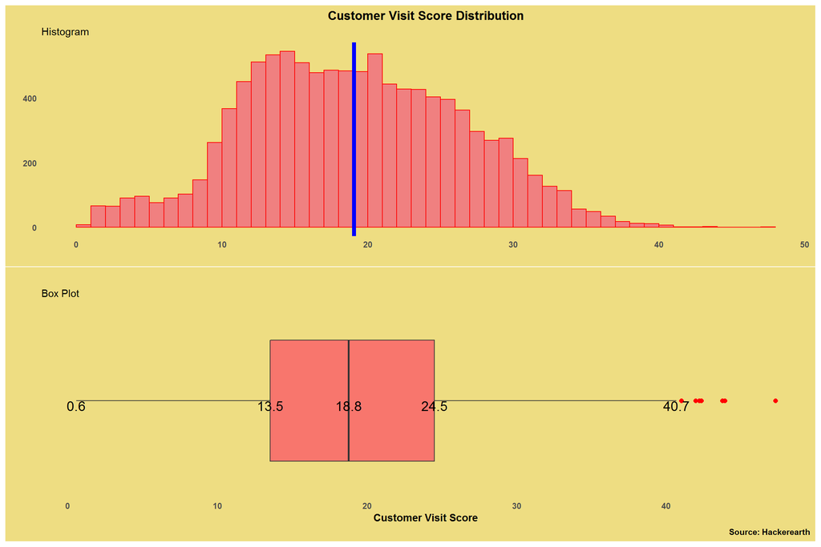

```r
tr_cust_score_his <- train %>%
  na.omit() %>%
  ggplot() +
  aes(x = customer_visit_score) +
  geom_histogram(breaks = visit_scorebin$breaks,
                 color="red",
                 fill="lightcoral"

  ) +
  geom_vline(aes(xintercept = mean(customer_visit_score)),
             col='blue',size=2)+

  theme_minimal() +
  labs(x = "",
       y = "",
       subtitle = "Histogram",
       title = "Customer Visit Score Distribution"
  ) +
  theme_dark() +
  theme(
    axis.ticks = element_blank(),
    axis.title = element_text(face = "bold"),
    axis.text = element_text(face = "bold"),
    plot.title = element_text(hjust = 0.5, face = "bold"),
    plot.caption = element_text(face = "bold"),
    legend.background = element_rect(fill = "transparent", colour = NA),
    panel.grid = element_blank(),
    plot.background = element_rect(fill = "lightgoldenrod"),
    panel.background = element_rect(fill = "transparent")
  )




tr_cust_score_box <- train %>%
  ggplot(aes(y="",x= customer_visit_score,fill="lightcoral")) +
  geom_boxplot(varwidth=T,
               outlier.color  = "red",
               outlier.size = 2) +

  stat_summary( geom="text", fun = box_summary,
                size=5,vjust=1,
                aes(
                  label=sprintf("%1.1f", ..x..))) +
  labs(x = "Customer Visit Score",
       y = "",
       subtitle = "Box Plot",
       caption = "Source: Hackerearth",
       title = "") +
  theme_dark() +
  theme(
    axis.ticks = element_blank(),
    axis.title = element_text(face = "bold"),
    axis.text = element_text(face = "bold"),
    plot.title = element_text(hjust = 0.5, face = "bold"),
    plot.caption = element_text(face = "bold"),
    legend.position = "none",
    panel.grid = element_blank(),
    plot.background = element_rect(fill = "lightgoldenrod"),
    panel.background = element_rect(fill = "transparent")
  )




tr_cust_score_his/tr_cust_score_box
```

#### The above histogram chart says that the customer visit scores are normally distributed and there is no skewness.

#### The boxplot says that that the median is 18.8 and there is more than one outlier data point (red points) outside the third quartile.

#### Let's analyze the customer visit score with more than one variable.

#### The following chart to analyze the customer visit score by various customer_active_segment and customer category.

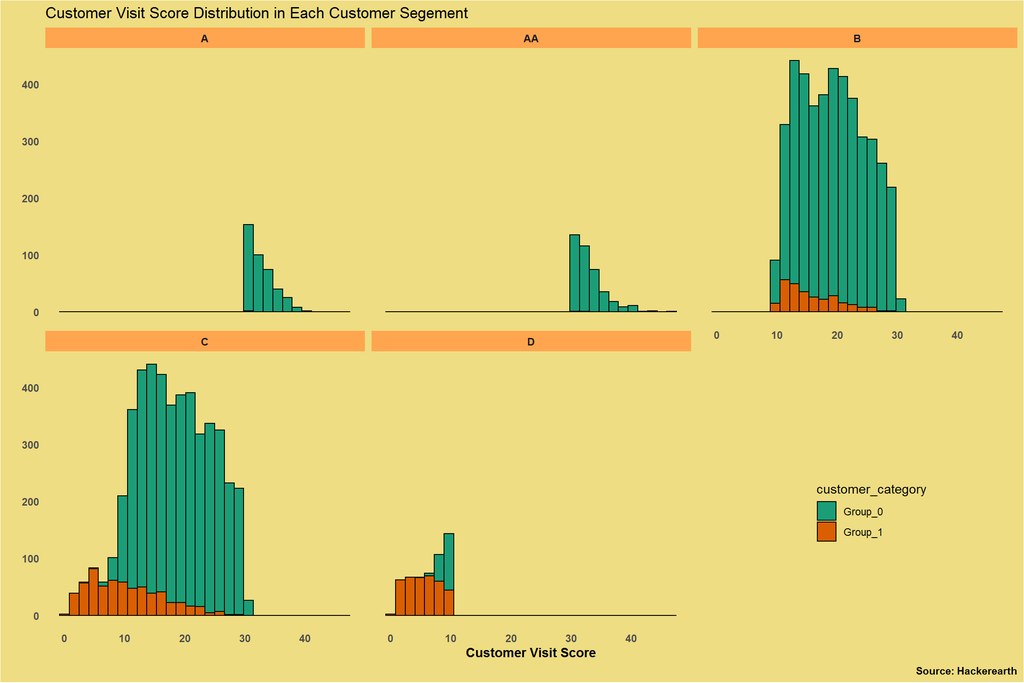

```r
train %>% mutate(customer_category =
                   recode(customer_category,
                          "0" = "Group_0",
                          "1" = "Group_1")) %>%
  na.omit() %>%
  ggplot(aes(x = customer_visit_score,
             fill = customer_category)) +
  geom_histogram(color = "black"
  ) +
  scale_fill_brewer(palette = "Dark2")+
  facet_wrap( ~ customer_active_segment)+
  labs(x="Customer Visit Score",y="",
       caption = "Source: Hackerearth",
       title = "Customer Visit Score Distribution in Each Customer Segement")+
  theme(
    axis.text = element_text(face = "bold"),
    axis.title.x =  element_text(face = "bold"),
    axis.ticks = element_blank(),
    legend.position = c(0.85,.20),
    panel.grid = element_blank(),
    strip.text = element_text(face = "bold"),
    strip.background.x = element_rect(fill = "tan1"),
    plot.background = element_rect(fill = "lightgoldenrod"),
    plot.caption = element_text(face = "bold"),
    panel.background = element_rect(fill = "transparent"),
    axis.line = element_blank(),
    legend.background = element_rect(fill = "transparent", colour = NA),
    legend.key = element_rect(fill = NA, color = NA)
  )
```

#### The above chart shows that the customer visit score range has different in each customer active segment. Customer category classification also shows a lot of differences.

#### In the next plot let's see any outlier points in customer visit score by various customer_active_segment and their category.

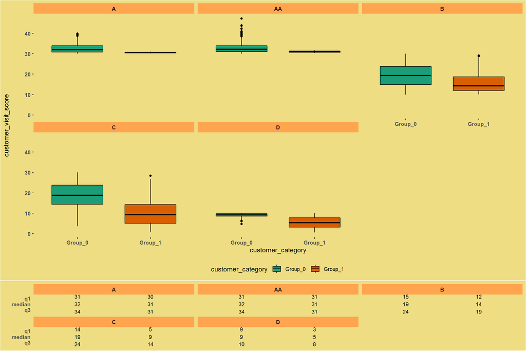

```r
ggsummarystats(
  train %>%
    mutate(customer_category =
             recode(customer_category,
                    "0" = "Group_0",
                    "1" = "Group_1")) %>%
    group_by(customer_active_segment,
             customer_category) %>%
    select(customer_active_segment,customer_category,
           customer_visit_score) %>%
    drop_na(),
  x = "customer_category",
  y = "customer_visit_score",
  ggfunc = ggboxplot,
  fill = "customer_category", palette = "Dark2",
  summaries = c("q1","median","q3"),
  labeller = "label_value",
  facet.by = "customer_active_segment",
  ggtheme = theme(axis.text = element_text(face = "bold"),
                  #axis.title.x =  element_text(face = "bold"),
                  axis.ticks = element_blank(),
                  legend.position = c(0.85,.20),
                  panel.grid = element_blank(),
                  strip.text = element_text(face = "bold"),
                  strip.background.x = element_rect(fill = "tan1"),
                  plot.background = element_rect(fill = "lightgoldenrod"),
                  panel.background = element_rect(fill = "transparent"),
                  axis.line = element_blank(),
                  legend.background = element_rect(fill = "transparent", colour = NA),
                  legend.key = element_rect(fill = NA, color = NA)),
  legend = "bottom"
)
```

#### The following chart to analyze the customer visit score by various categories of Anonymized variable(X1) and customer category.

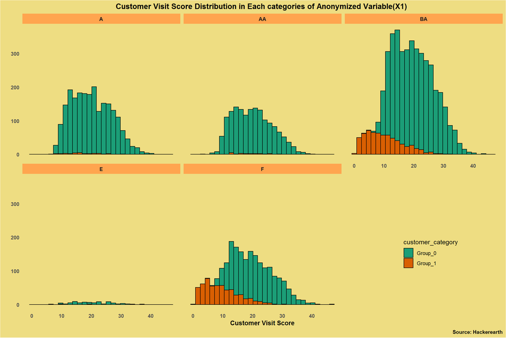

```r
train %>% mutate(customer_category =
                   recode(customer_category,
                          "0" = "Group_0",
                          "1" = "Group_1")) %>%
  na.omit() %>%
  ggplot(aes(x = customer_visit_score,
             fill = customer_category)) +
  geom_histogram(color = "black"
  ) +
  scale_fill_brewer(palette = "Dark2")+
  facet_wrap( ~ X1)+
  labs(x="Customer Visit Score",y="",caption = "Source: Hackerearth",
       title = "Customer Visit Score Distribution in Each categories of Anonymized Variable(X1) ")+
  theme(
    axis.text = element_text(face = "bold"),
    axis.title.x =  element_text(face = "bold"),
    axis.ticks = element_blank(),
    legend.position = c(0.85,.20),
    panel.grid = element_blank(),
    strip.text = element_text(face = "bold"),
    strip.background.x = element_rect(fill = "tan1"),
    plot.background = element_rect(fill = "lightgoldenrod"),
     plot.caption = element_text(face = "bold"),
      plot.title =  element_text(face = "bold",hjust = 0.5),
    panel.background = element_rect(fill = "transparent"),
    axis.line = element_blank(),
    legend.background = element_rect(fill = "transparent", colour = NA),
    legend.key = element_rect(fill = NA, color = NA)
  )
```

#### The above chart shows that customer visit score have a different distribution in each category of Anonymized variables(X1) and customer category.

#### Anonymized variable(X1) Category E has less number of customers.

#### In the next plot let's see any outlier points in customer visit score by various categories of Anonymized variables(X1) and customer category.

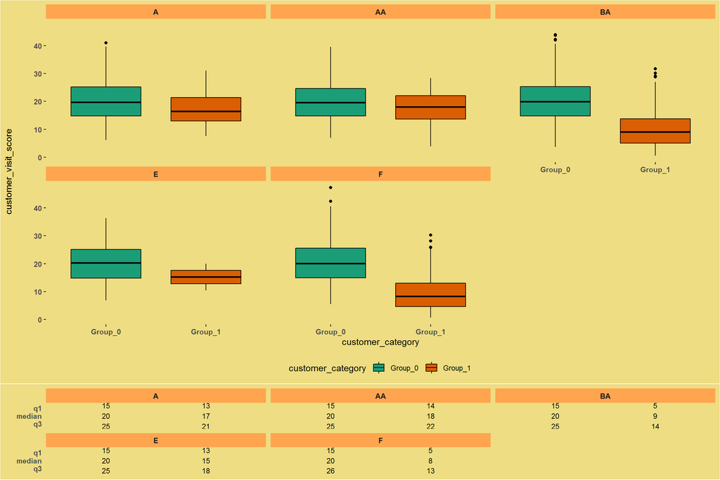

```r
ggsummarystats(
  train %>%
    mutate(customer_category =
             recode(customer_category,
                    "0" = "Group_0",
                    "1" = "Group_1")) %>%
    group_by(X1,
             customer_category) %>%
    select(X1,customer_category,
           customer_visit_score) %>%
    drop_na(),
  x = "customer_category",
  y = "customer_visit_score",
  ggfunc = ggboxplot,
  fill = "customer_category", palette = "Dark2",
  summaries = c("q1","median","q3"),
  labeller = "label_value",
  facet.by = "X1",
  ggtheme = theme(axis.text = element_text(face = "bold"),
                  #axis.title.x =  element_text(face = "bold"),
                  axis.ticks = element_blank(),
                  legend.position = c(0.85,.20),
                  panel.grid = element_blank(),
                  strip.text = element_text(face = "bold"),
                  strip.background.x = element_rect(fill = "tan1"),
                  plot.background = element_rect(fill = "lightgoldenrod"),
                  panel.background = element_rect(fill = "transparent"),
                  axis.line = element_blank(),
                  legend.background = element_rect(fill = "transparent", colour = NA),
                  legend.key = element_rect(fill = NA, color = NA)), legend = "bottom"
)
```

#### The above chart shows that the Anonymized variable(X1) not have more number of outliers in all levels of Anonymized variable(X1).

### Customer Product Search Score

#### Let's check the customer_product_search_score

#### customer product search score, the score is based on the type of product and its price range searched by the customer.

#### As mentioned in the problem statement, a customer searching for a laptop will have more weightage than someone looking for a book.

#### Let's look quick summary of customer product search score

```r
summary(train$customer_product_search_score)
```

```
##    Min. 1st Qu.  Median    Mean 3rd Qu.    Max.    NA's
## -0.1619  3.9716  5.2185  5.2748  6.5204 16.6382      42
```

#### The summary shows a negative search score is there and the mean is 5.2748.

#### binwidth selected by using Freedman–Diaconis rule.

```r
prod_sear_scorebin<-hist(train$customer_product_search_score,breaks = "FD",plot = F)
```

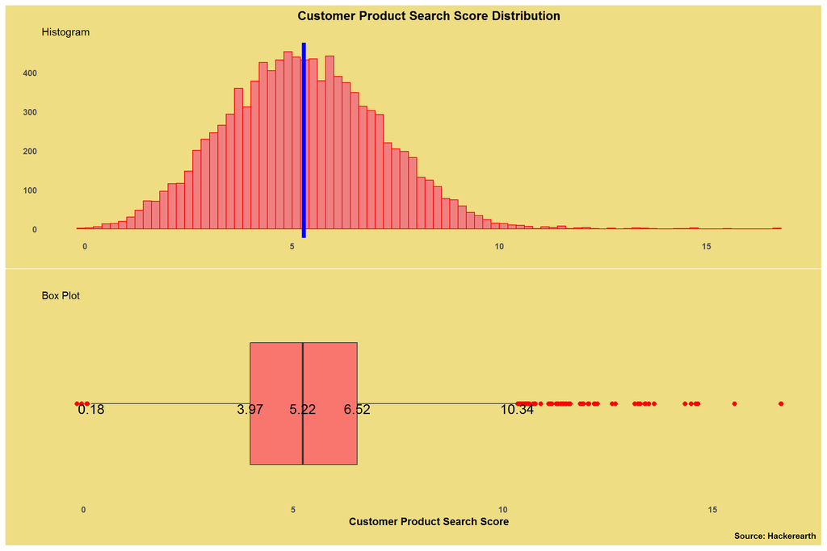

```r
prod_sear_score_his <- train %>%
  na.omit() %>%
  ggplot() +
  aes(x = customer_product_search_score) +
  geom_histogram(breaks = prod_sear_scorebin$breaks,
                 color="red",
                 fill="lightcoral"

  ) +
  geom_vline(aes(xintercept = mean(customer_product_search_score)),
             col='blue',size=2)+

  theme_minimal() +
  labs(x = "",
       y = "",
       subtitle = "Histogram",
       title = "Customer Product Search Score Distribution"
  ) +
  theme_dark() +
  theme(
    axis.ticks = element_blank(),
    axis.title = element_text(face = "bold"),
    axis.text = element_text(face = "bold"),
    plot.title = element_text(hjust = 0.5, face = "bold"),
    plot.caption = element_text(face = "bold"),
    legend.background = element_rect(fill = "transparent", colour = NA),
    panel.grid = element_blank(),
    plot.background = element_rect(fill = "lightgoldenrod"),
    panel.background = element_rect(fill = "transparent")
  )






prod_sear_score_box <- train %>%
  ggplot(aes(y="",x= customer_product_search_score,fill="lightcoral")) +
  geom_boxplot(varwidth=T,
               outlier.color  = "red",
               outlier.size = 2) +

  stat_summary( geom="text", fun = box_summary ,
                size=5,vjust=1,
                #fun.args=list(probs=c(0,.5,.25,.75)),
                aes(
                  label=sprintf("%1.2f", ..x..))) +
  labs(x = "Customer Product Search Score",
       y = "",
       subtitle = "Box Plot",
       caption = "Source: Hackerearth",
       title = "") +
  theme_dark() +
  theme(
    axis.ticks = element_blank(),
    axis.title = element_text(face = "bold"),
    axis.text = element_text(face = "bold"),
    plot.title = element_text(hjust = 0.5, face = "bold"),
    plot.caption = element_text(face = "bold"),
    legend.position = "none",
    panel.grid = element_blank(),
    plot.background = element_rect(fill = "lightgoldenrod"),
    panel.background = element_rect(fill = "transparent")
  )




prod_sear_score_his/prod_sear_score_box
```

#### The above histogram chart says that the customer product search score is normally distributed and there is no skewness.

#### The box plot explains there are outliers(high weightage product search score) in the outside upper and lower limits.

#### Let's analyze the customer product search score with more than one variable.

#### The following chart to analyze the customer product search score by various customer_active_segment and customer category.

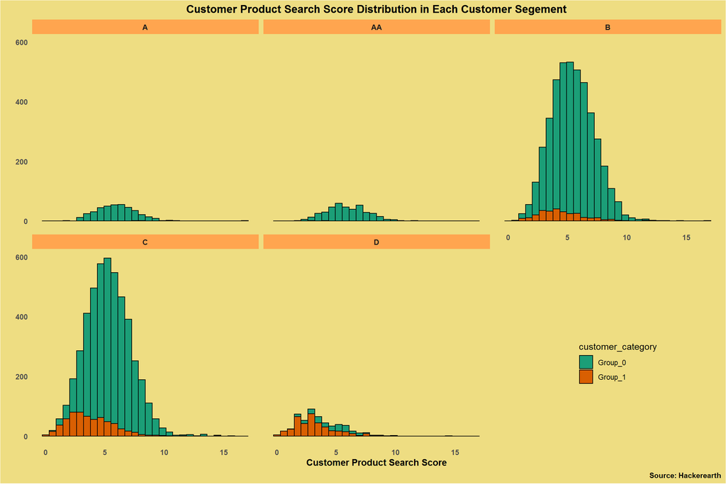

```r
train %>% mutate(customer_category =
                   recode(customer_category,
                          "0" = "Group_0",
                          "1" = "Group_1")) %>%
  na.omit() %>%
  ggplot(aes(x = customer_product_search_score,
             fill = customer_category)) +
  geom_histogram(color = "black"
  ) +
  scale_fill_brewer(palette = "Dark2")+
  facet_wrap( ~ customer_active_segment)+
  labs(x="Customer Product Search Score",y="",caption = "Source: Hackerearth",
       title = "Customer Product Search Score Distribution in Each Customer Segement")+
  theme(
    axis.text = element_text(face = "bold"),
    axis.title.x =  element_text(face = "bold"),
    axis.ticks = element_blank(),
    legend.position = c(0.85,.20),
    panel.grid = element_blank(),
    strip.text = element_text(face = "bold"),
    strip.background.x = element_rect(fill = "tan1"),
    plot.background = element_rect(fill = "lightgoldenrod"),
    plot.caption = element_text(face = "bold"),
    plot.title = element_text(face = "bold",hjust = 0.5),
    panel.background = element_rect(fill = "transparent"),
    axis.line = element_blank(),
    legend.background = element_rect(fill = "transparent", colour = NA),
    legend.key = element_rect(fill = NA, color = NA)
  )
```

#### The above chart shows that the customer product search score range has different in each customer active segment. Customer category classification also shows a lot of differences.

#### In the next plot let's see any outlier points in customer product search score by various customer_active_segment and Customer category.

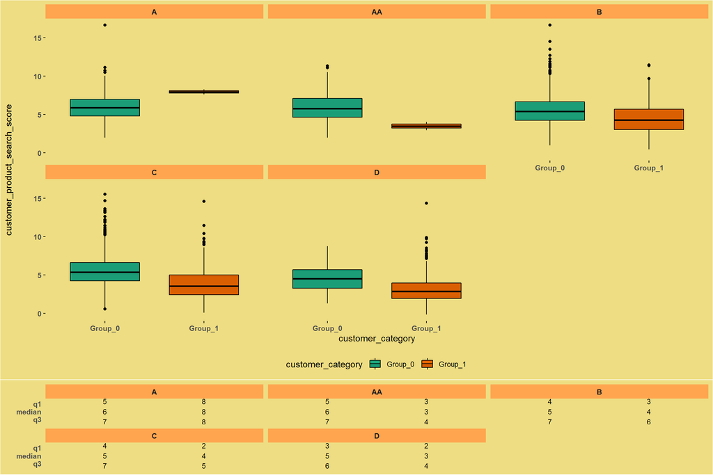

```r
ggsummarystats(
  train %>%
    mutate(customer_category =
             recode(customer_category,
                    "0" = "Group_0",
                    "1" = "Group_1")) %>%
    group_by(customer_active_segment,
             customer_category) %>%
    select(customer_active_segment,customer_category,
           customer_product_search_score) %>%
    drop_na(),
  x = "customer_category",
  y = "customer_product_search_score",
  ggfunc = ggboxplot,
  fill = "customer_category", palette = "Dark2",
  summaries = c("q1","median","q3"),
  labeller = "label_value",
  facet.by = "customer_active_segment",
  ggtheme = theme(axis.text = element_text(face = "bold"),
                  #axis.title.x =  element_text(face = "bold"),
                  axis.ticks = element_blank(),
                  legend.position = c(0.85,.20),
                  panel.grid = element_blank(),
                  strip.text = element_text(face = "bold"),
                  strip.background.x = element_rect(fill = "tan1"),
                  plot.background = element_rect(fill = "lightgoldenrod"),
                  panel.background = element_rect(fill = "transparent"),
                  axis.line = element_blank(),
                  legend.background = element_rect(fill = "transparent", colour = NA),
                  legend.key = element_rect(fill = NA, color = NA)),
  legend = "bottom"
)
```

#### The above chart shows that there are a lot of outliers(high weightage product search score) in B, C, and D active Segment and customer category.

#### The following chart to analyze the customer product search score by various category of Anonymized variables(X1) and customer category.

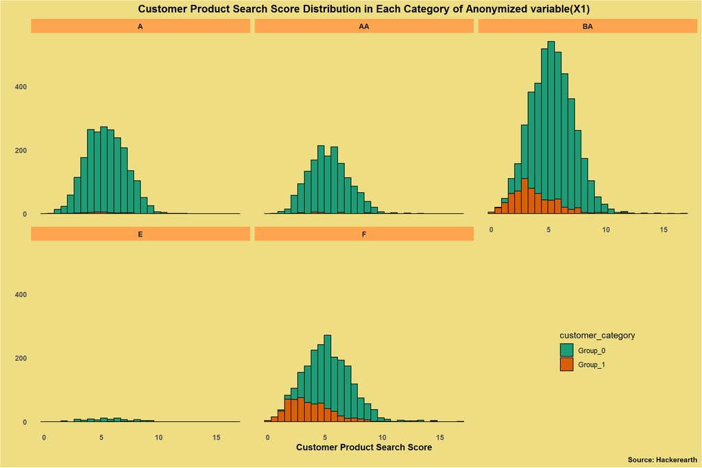

```r
train %>% mutate(customer_category =
                   recode(customer_category,
                          "0" = "Group_0",
                          "1" = "Group_1")) %>%
  na.omit() %>%
  ggplot(aes(x = customer_product_search_score,
             fill = customer_category)) +
  geom_histogram(color = "black"
  ) +
  scale_fill_brewer(palette = "Dark2")+
  facet_wrap( ~ X1)+
  labs(x="Customer Product Search Score",y="",caption = "Source: Hackerearth",
       title = "Customer Product Search Score Distribution in Each Category of Anonymized variable(X1)")+
  theme(
    axis.text = element_text(face = "bold"),
    axis.title.x =  element_text(face = "bold"),
    axis.ticks = element_blank(),
    legend.position = c(0.85,.20),
    panel.grid = element_blank(),
    strip.text = element_text(face = "bold"),
    plot.caption = element_text(face = "bold"),
    plot.title = element_text(face = "bold",hjust = 0.5),
    strip.background.x = element_rect(fill = "tan1"),
    plot.background = element_rect(fill = "lightgoldenrod"),
    panel.background = element_rect(fill = "transparent"),
    axis.line = element_blank(),
    legend.background = element_rect(fill = "transparent", colour = NA),
    legend.key = element_rect(fill = NA, color = NA)
  )
```

#### Let's check the customer product search score by various categories of Anonymized variables(X1) and customer category.

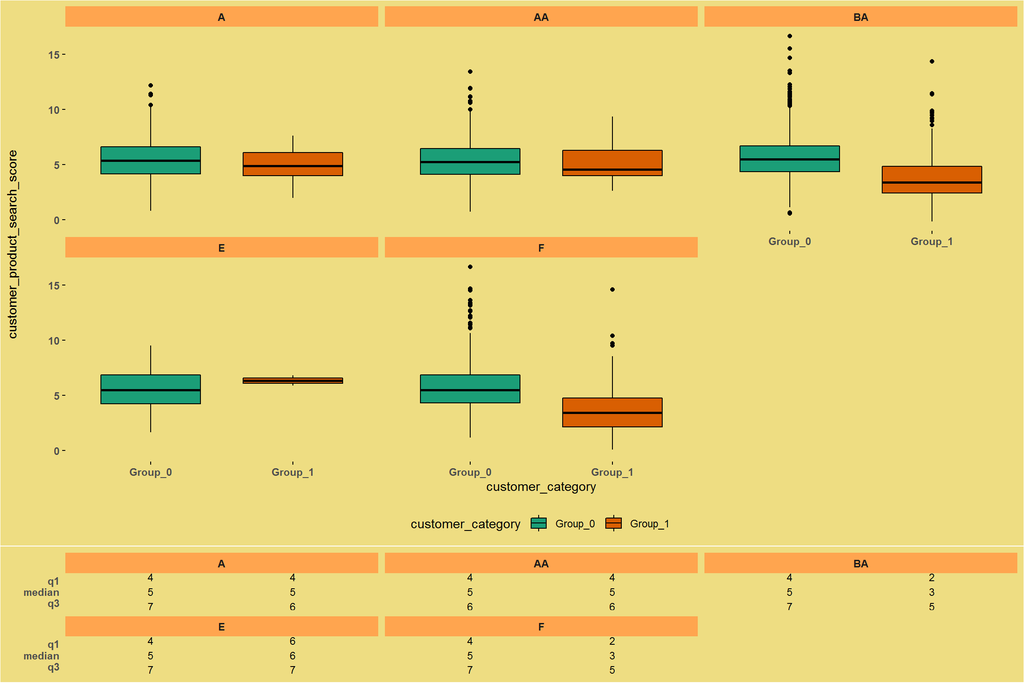

```r
ggsummarystats(
  train %>%
    mutate(customer_category =
             recode(customer_category,
                    "0" = "Group_0",
                    "1" = "Group_1")) %>%
    group_by(X1,
             customer_category) %>%
    select(X1,customer_category,
           customer_product_search_score) %>%
    drop_na(),
  x = "customer_category",
  y = "customer_product_search_score",
  ggfunc = ggboxplot,
  fill = "customer_category", palette = "Dark2",
  summaries = c("q1","median","q3"),
  labeller = "label_value",

  facet.by = "X1",
  ggtheme = theme(axis.text = element_text(face = "bold"),
                  #axis.title.x =  element_text(face = "bold"),
                  axis.ticks = element_blank(),
                  legend.position = c(0.85,.20),
                  panel.grid = element_blank(),
                  strip.text = element_text(face = "bold"),
                  strip.background.x = element_rect(fill = "tan1"),
                  plot.background = element_rect(fill = "lightgoldenrod"),
                  panel.background = element_rect(fill = "transparent"),
                  axis.line = element_blank(),
                  legend.background = element_rect(fill = "transparent", colour = NA),
                  legend.key = element_rect(fill = NA, color = NA)
  ) ,legend = "bottom"
)
```

#### The above chart shows that there are a lot of outliers(high weightage product search score) in categories A, AA, BA, and F of Anonymized variables(X1) and customer category.

### Customer Click Score

#### Let's check the customer ctr score

#### customer ctr score, the score based on the searched link clicks.

#### For example, a customer has searched for headphones then so many brand links will appear, in that how many links customers will click. The number of link clicks will be converted into scores.

#### Let's look quick summary of the customer ctr score

```r
summary(train$customer_ctr_score)
```

```
##     Min.  1st Qu.   Median     Mean  3rd Qu.     Max.
## -0.54799  0.01084  0.07408  0.17591  0.15961  2.67947
```

#### The summary shows a negative ctr score is there and the mean is 0.17591.

#### binwidth selected by using Freedman–Diaconis rule.

```r
customer_ctr_scorebin<-hist(train$customer_ctr_score,breaks = "FD",plot = F)
```

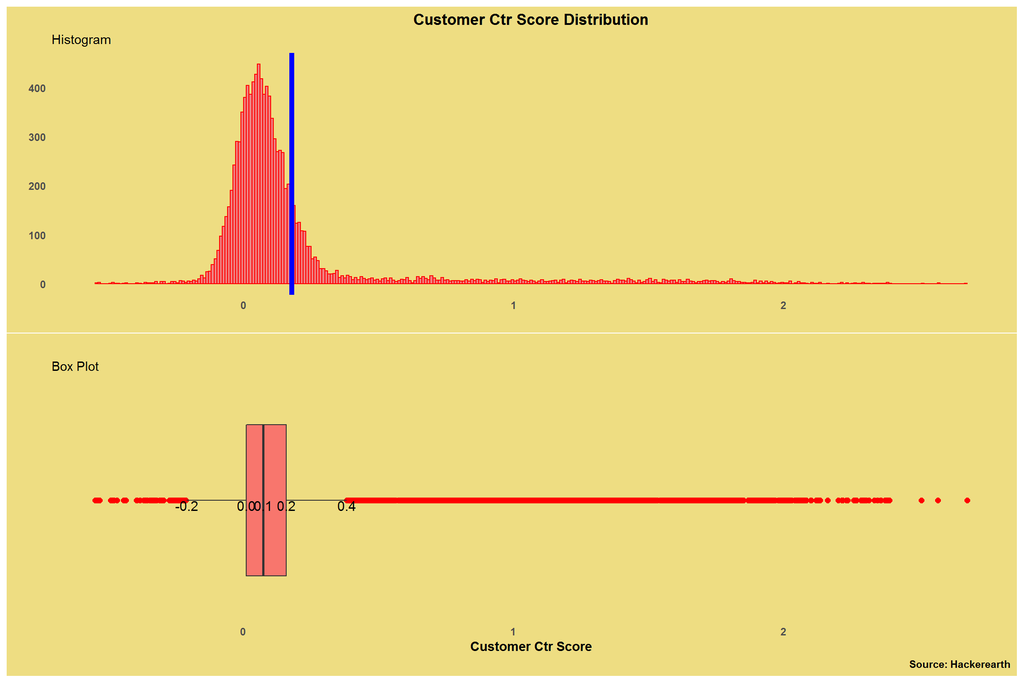

```r
customer_ctr_score_his <- train %>%
  na.omit() %>%
  ggplot() +
  aes(x = customer_ctr_score) +
  geom_histogram(breaks = customer_ctr_scorebin$breaks,
                 color="red",
                 fill="lightcoral"

  ) +
  geom_vline(aes(xintercept = mean(customer_ctr_score)),
             col='blue',size=2)+

  theme_minimal() +
  labs(x = "",
       y = "",
       subtitle = "Histogram",
       title = "Customer Ctr Score Distribution"
  ) +
  theme_dark() +
  theme(
    axis.ticks = element_blank(),
    axis.title = element_text(face = "bold"),
    axis.text = element_text(face = "bold"),
    plot.title = element_text(hjust = 0.5, face = "bold"),
    plot.caption = element_text(face = "bold"),
    legend.background = element_rect(fill = "transparent", colour = NA),
    panel.grid = element_blank(),
    plot.background = element_rect(fill = "lightgoldenrod"),
    panel.background = element_rect(fill = "transparent")
  )


customer_ctr_score_box <- train %>%
  ggplot(aes(y="",x= customer_ctr_score,fill="lightcoral")) +
  geom_boxplot(varwidth=T,
               outlier.color  = "red",
               outlier.size = 2) +

  stat_summary( geom="text", fun = box_summary ,
                size=4,vjust=1,
                #fun.args=list(probs=c(0,.5,.25,.75)),
                aes(
                  label=sprintf("%0.1f", ..x..))) +
  labs(x = "Customer Ctr Score",
       y = "",
       subtitle = "Box Plot",
       caption = "Source: Hackerearth",
       title = "") +
  theme_dark() +
  theme(
    axis.ticks = element_blank(),
    axis.title = element_text(face = "bold"),
    axis.text = element_text(face = "bold"),
    plot.title = element_text(hjust = 0.5, face = "bold"),
    plot.caption = element_text(face = "bold"),
    legend.position = "none",
    panel.grid = element_blank(),
    plot.background = element_rect(fill = "lightgoldenrod"),
    panel.background = element_rect(fill = "transparent")
  )




customer_ctr_score_his/customer_ctr_score_box
```

#### The above histogram chart says that the customer ctr score is right-skewed(most of the click link score falls below the mean).

#### The boxplot explains there are outliers in the outside upper and lower limits.

#### Let's analyze the customer ctr score with more than one variable.

#### The following chart to analyze the customer ctr score by various customer_active_segment and customer category.

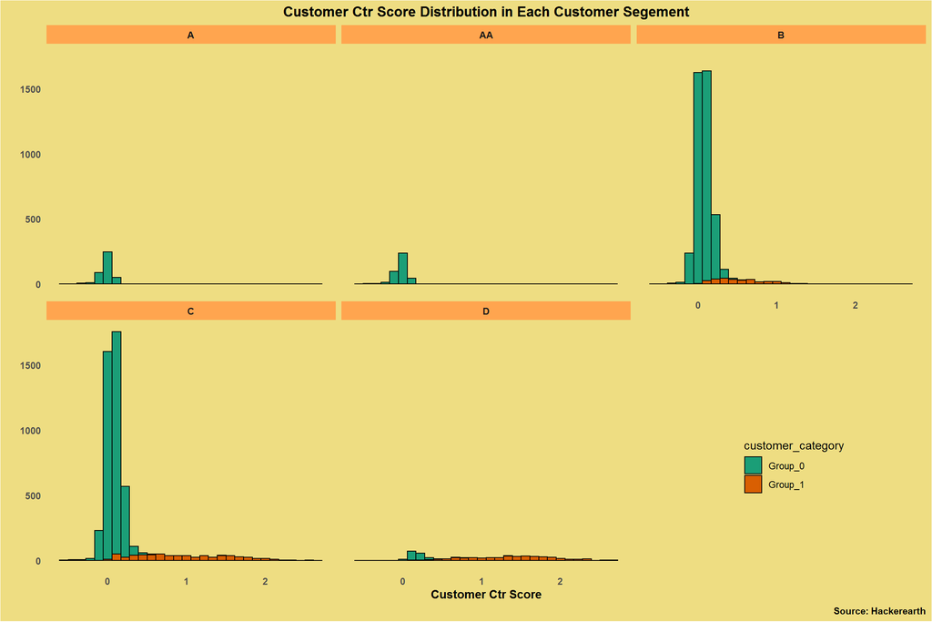

```r
train %>% mutate(customer_category =
                   recode(customer_category,
                          "0" = "Group_0",
                          "1" = "Group_1")) %>%
  na.omit() %>%
  ggplot(aes(x = customer_ctr_score,
             fill = customer_category)) +
  geom_histogram(color = "black"
  ) +
  scale_fill_brewer(palette = "Dark2")+
  facet_wrap( ~ customer_active_segment)+
  labs(x="Customer Ctr Score",y="",caption = "Source: Hackerearth",
       title = "Customer Ctr Score Distribution in Each Customer Segement")+
  theme(
    axis.text = element_text(face = "bold"),
    axis.title.x =  element_text(face = "bold"),
    axis.ticks = element_blank(),
    legend.position = c(0.85,.20),
    panel.grid = element_blank(),
    strip.text = element_text(face = "bold"),
    strip.background.x = element_rect(fill = "tan1"),
    plot.background = element_rect(fill = "lightgoldenrod"),
    panel.background = element_rect(fill = "transparent"),
    plot.caption = element_text(face = "bold"),
    plot.title = element_text(face = "bold",hjust = 0.5),
    axis.line = element_blank(),
    legend.background = element_rect(fill = "transparent", colour = NA),
    legend.key = element_rect(fill = NA, color = NA)
  )
```

#### The above chart shows that the customer ctr score range has different in each customer active segment. Customer category classification also shows a lot of differences.

#### In the next plot let's see any outlier points in customer ctr score by various customer_active_segment and Customer category.

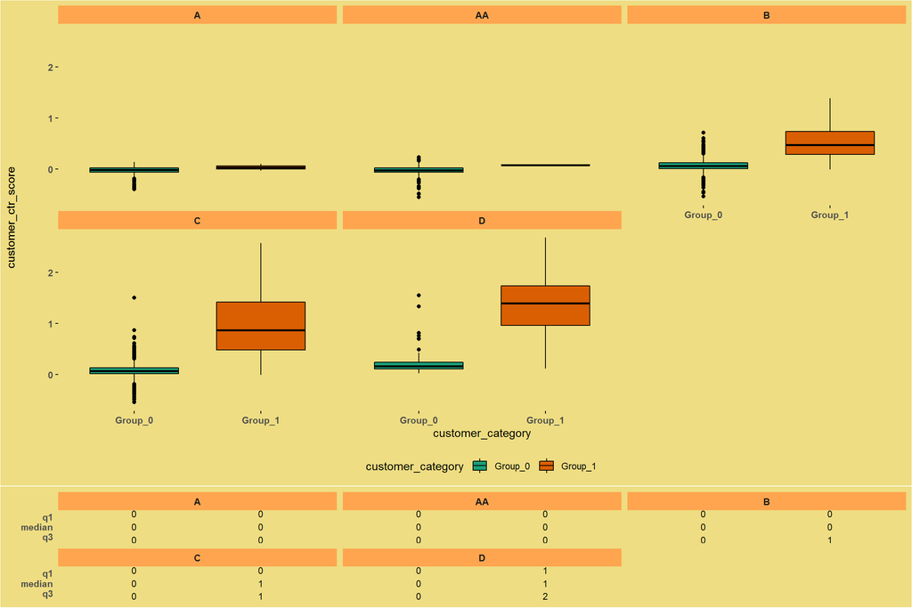

```r
ggsummarystats(
  train %>%
    mutate(customer_category =
             recode(customer_category,
                    "0" = "Group_0",
                    "1" = "Group_1")) %>%
    group_by(customer_active_segment,
             customer_category) %>%
    select(customer_active_segment,customer_category,
           customer_ctr_score) %>%
    drop_na(),
  x = "customer_category",
  y = "customer_ctr_score",
  ggfunc = ggboxplot,
  fill = "customer_category", palette = "Dark2",
  summaries = c("q1","median","q3"),
  labeller = "label_value",
  facet.by = "customer_active_segment",
  ggtheme = theme(axis.text = element_text(face = "bold"),
                  #axis.title.x =  element_text(face = "bold"),
                  axis.ticks = element_blank(),
                  legend.position = c(0.85,.20),
                  panel.grid = element_blank(),
                  strip.text = element_text(face = "bold"),
                  strip.background.x = element_rect(fill = "tan1"),
                  plot.background = element_rect(fill = "lightgoldenrod"),
                  panel.background = element_rect(fill = "transparent"),
                  axis.line = element_blank(),
                  legend.background = element_rect(fill = "transparent", colour = NA),
                  legend.key = element_rect(fill = NA, color = NA)),
  legend = "bottom"
)
```

#### The above chart shows that the group_0 customer category has more number of outliers in all the active Segments.

#### The following chart to analyze the customer ctr score by various category of Anonymized variable(X1) and customer category.

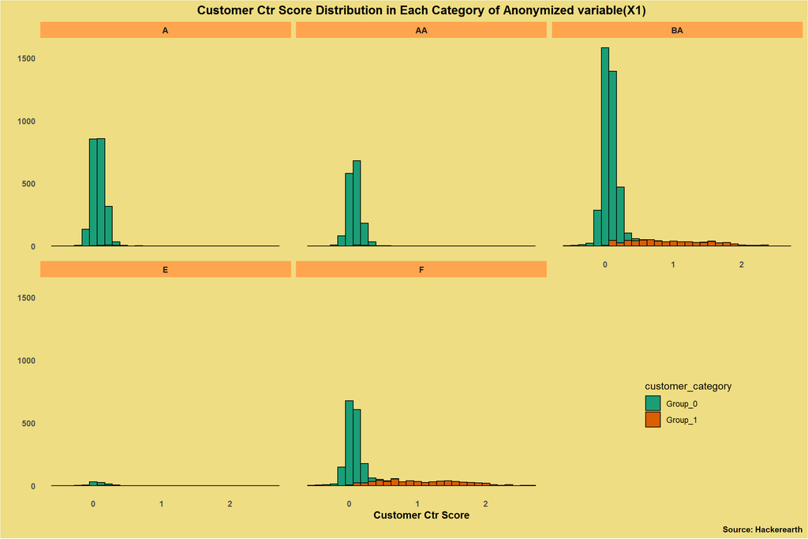

```r
train %>% mutate(customer_category =
                   recode(customer_category,
                          "0" = "Group_0",
                          "1" = "Group_1")) %>%
  na.omit() %>%
  ggplot(aes(x = customer_ctr_score,
             fill = customer_category)) +
  geom_histogram(color = "black"
  ) +
  scale_fill_brewer(palette = "Dark2")+
  facet_wrap( ~ X1)+
  labs(x="Customer Ctr Score",y="",caption = "Source: Hackerearth",
       title = "Customer Ctr Score Distribution in Each Category of Anonymized variable(X1)")+
  theme(
    axis.text = element_text(face = "bold"),
    axis.title.x =  element_text(face = "bold"),
    axis.ticks = element_blank(),
    legend.position = c(0.85,.20),
    panel.grid = element_blank(),
    strip.text = element_text(face = "bold"),
    strip.background.x = element_rect(fill = "tan1"),
    plot.background = element_rect(fill = "lightgoldenrod"),
    plot.caption = element_text(face = "bold"),
    plot.title = element_text(face = "bold",hjust = 0.5),
    panel.background = element_rect(fill = "transparent"),
    axis.line = element_blank(),
    legend.background = element_rect(fill = "transparent", colour = NA),
    legend.key = element_rect(fill = NA, color = NA)
  )
```

#### Let's check the customer ctr score by various categories of Anonymized variable(X1) and customer category.

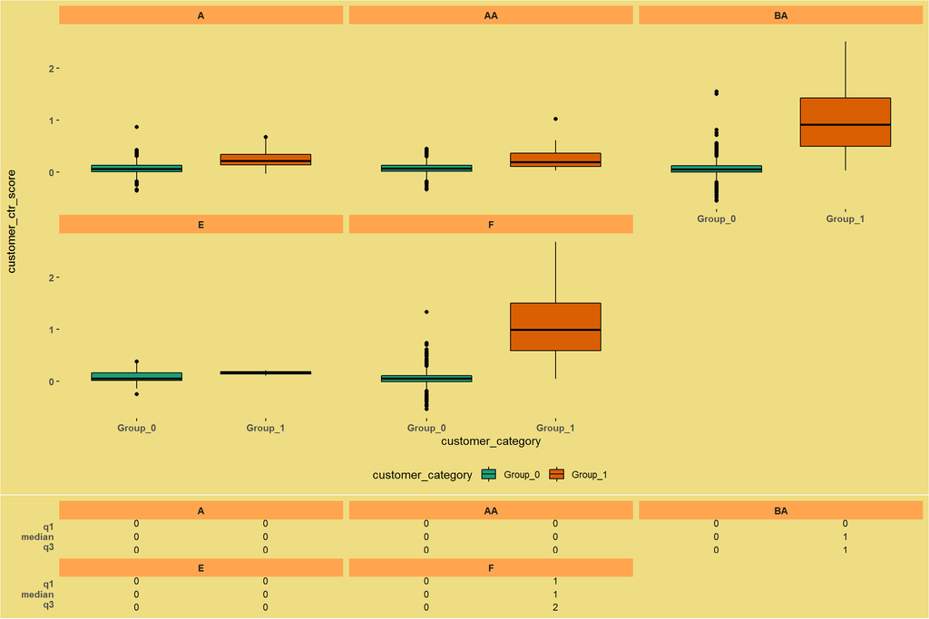

```r
ggsummarystats(
  train %>%
    mutate(customer_category =
             recode(customer_category,
                    "0" = "Group_0",
                    "1" = "Group_1")) %>%
    group_by(X1,
             customer_category) %>%
    select(X1,customer_category,
           customer_ctr_score) %>%
    drop_na(),
  x = "customer_category",
  y = "customer_ctr_score",
  ggfunc = ggboxplot,
  fill = "customer_category", palette = "Dark2",
  summaries = c("q1","median","q3"),
  labeller = "label_value",

  facet.by = "X1",
  ggtheme = theme(axis.text = element_text(face = "bold"),
                  #axis.title.x =  element_text(face = "bold"),
                  axis.ticks = element_blank(),
                  legend.position = c(0.85,.20),
                  panel.grid = element_blank(),
                  strip.text = element_text(face = "bold"),
                  strip.background.x = element_rect(fill = "tan1"),
                  plot.background = element_rect(fill = "lightgoldenrod"),
                  panel.background = element_rect(fill = "transparent"),
                  axis.line = element_blank(),
                  legend.background = element_rect(fill = "transparent", colour = NA),
                  legend.key = element_rect(fill = NA, color = NA)
  ) ,legend = "bottom"
)
```

### Customer Stay Score

#### Let's check the customer stay score

#### customer stay score, the score based on the average time spent on the website by the customer.

#### Let's look quick summary of customer stay score

```r
summary(train$customer_stay_score)
```

```
##     Min.  1st Qu.   Median     Mean  3rd Qu.     Max.     NA's
## -0.46249 -0.02767  0.03720  0.37423  0.17903 14.70191       37
```

#### The summary shows a negative search score is there and the mean is 0.37423.

#### binwidth selected by using Freedman–Diaconis rule.

```r
customer_stay_scorebin<-hist(train$customer_stay_score,breaks = "FD",plot = F)
```

```r
customer_stay_score_his <- train %>%
  na.omit() %>%
  ggplot() +
  aes(x = customer_stay_score) +
  geom_histogram(breaks = customer_stay_scorebin$breaks,
                 color="red",
                 fill="lightcoral"

  ) +
  geom_vline(aes(xintercept = mean(customer_stay_score)),
             col='blue',size=2)+

  theme_minimal() +
  labs(x = "",
       y = "",
       subtitle = "Histogram",
       title = "Customer Stay Score Distribution"
  ) +
  theme_dark() +
  theme(
    axis.ticks = element_blank(),
    axis.title = element_text(face = "bold"),
    axis.text = element_text(face = "bold"),
    plot.title = element_text(hjust = 0.5, face = "bold"),
    plot.caption = element_text(face = "bold"),
    legend.background = element_rect(fill = "transparent", colour = NA),
    panel.grid = element_blank(),
    plot.background = element_rect(fill = "lightgoldenrod"),
    panel.background = element_rect(fill = "transparent")
  )



customer_stay_score_box <- train %>%
  ggplot(aes(y="",x= customer_stay_score,fill="lightcoral")) +
  geom_boxplot(varwidth=T,
               outlier.color  = "red",
               outlier.size = 2) +

  # stat_summary( geom="text", fun = box_summary ,
  #               size=4,vjust=1,
  #               #fun.args=list(probs=c(0,.5,.25,.75)),
  #               aes(
  #                 label=sprintf("%0.1f", ..x..))) +
  labs(x = "Customer Stay Score",
       y = "",
       subtitle = "Box Plot",
       caption = "Source: Hackerearth",
       title = "") +
  theme_dark() +
  theme(
    axis.ticks = element_blank(),
    axis.title = element_text(face = "bold"),
    axis.text = element_text(face = "bold"),
    plot.title = element_text(hjust = 0.5, face = "bold"),
    plot.caption = element_text(face = "bold"),
    legend.position = "none",
    panel.grid = element_blank(),
    plot.background = element_rect(fill = "lightgoldenrod"),
    panel.background = element_rect(fill = "transparent")
  )

box_summary(train$customer_stay_score)
```

```
## [1] -0.33291271 -0.02766573  0.03720079  0.17902877  0.48893389
```

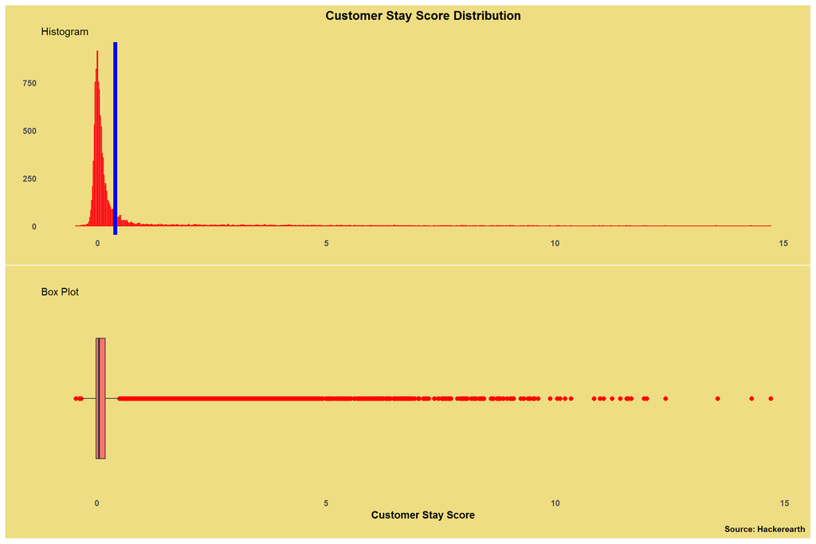

```r
customer_stay_score_his/customer_stay_score_box
```

#### The above histogram chart says that the customer stay score is right-skewed(most of the customer stay score falls below the mean).

#### The box plot explains there are outliers in the outside upper and lower limits.

#### Let's analyze the customer stay score with more than one variable.

#### The following chart to analyze the customer stay score by various customer_active_segment and customer category.

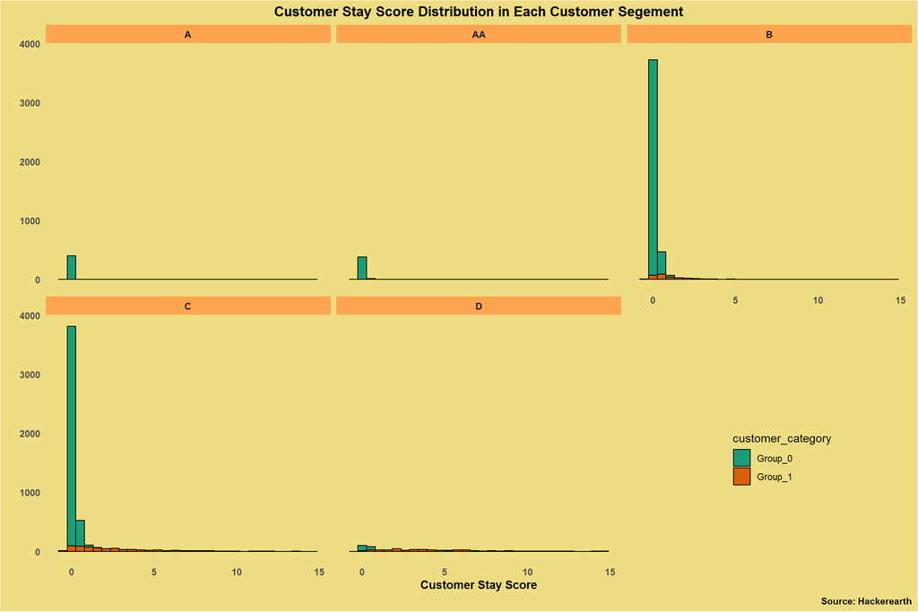

```r
train %>% mutate(customer_category =
                   recode(customer_category,
                          "0" = "Group_0",
                          "1" = "Group_1")) %>%
  na.omit() %>%
  ggplot(aes(x = customer_stay_score,
             fill = customer_category)) +
  geom_histogram(color = "black"
  ) +
  scale_fill_brewer(palette = "Dark2")+
  facet_wrap( ~ customer_active_segment)+
  labs(x="Customer Stay Score",y="",caption = "Source: Hackerearth",
       title = "Customer Stay Score Distribution in Each Customer Segement")+
  theme(
    axis.text = element_text(face = "bold"),
    axis.title.x =  element_text(face = "bold"),
    axis.ticks = element_blank(),
    legend.position = c(0.85,.20),
    panel.grid = element_blank(),
    strip.text = element_text(face = "bold"),
    strip.background.x = element_rect(fill = "tan1"),
    plot.background = element_rect(fill = "lightgoldenrod"),
    plot.caption = element_text(face = "bold"),
    plot.title = element_text(face = "bold",hjust = 0.5),
    panel.background = element_rect(fill = "transparent"),
    axis.line = element_blank(),
    legend.background = element_rect(fill = "transparent", colour = NA),
    legend.key = element_rect(fill = NA, color = NA)
  )
```

#### The above chart shows that the customer stay score range has different in each customer active segment. Customer category classification also shows a lot of differences.

#### In the next plot let's see any outlier points in customer stay score by various customer_active_segment and Customer category.

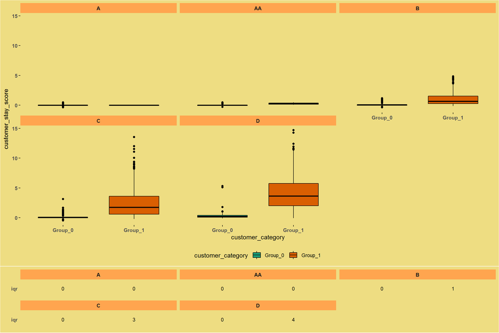

```r
ggsummarystats(
  train %>%
    mutate(customer_category =
             recode(customer_category,
                    "0" = "Group_0",
                    "1" = "Group_1")) %>%
    group_by(customer_active_segment,
             customer_category) %>%
    select(customer_active_segment,customer_category,
           customer_stay_score) %>%
    drop_na(),
  x = "customer_category",
  y = "customer_stay_score",
  ggfunc = ggboxplot,
  fill = "customer_category", palette = "Dark2",
  summaries = "iqr",
  labeller = "label_value",
  facet.by = "customer_active_segment",
  ggtheme = theme(axis.text = element_text(face = "bold"),
                  #axis.title.x =  element_text(face = "bold"),
                  axis.ticks = element_blank(),
                  legend.position = c(0.85,.20),
                  panel.grid = element_blank(),
                  strip.text = element_text(face = "bold"),
                  strip.background.x = element_rect(fill = "tan1"),
                  plot.background = element_rect(fill = "lightgoldenrod"),
                  panel.background = element_rect(fill = "transparent"),
                  axis.line = element_blank(),
                  legend.background = element_rect(fill = "transparent", colour = NA),
                  legend.key = element_rect(fill = NA, color = NA)),
  legend = "bottom"
)
```

#### The above chart shows that both customer categories have more number of outliers in the B, C, and D active Segment.

#### The following chart to analyze the customer ctr score by various category of Anonymized variable(X1) and customer category.

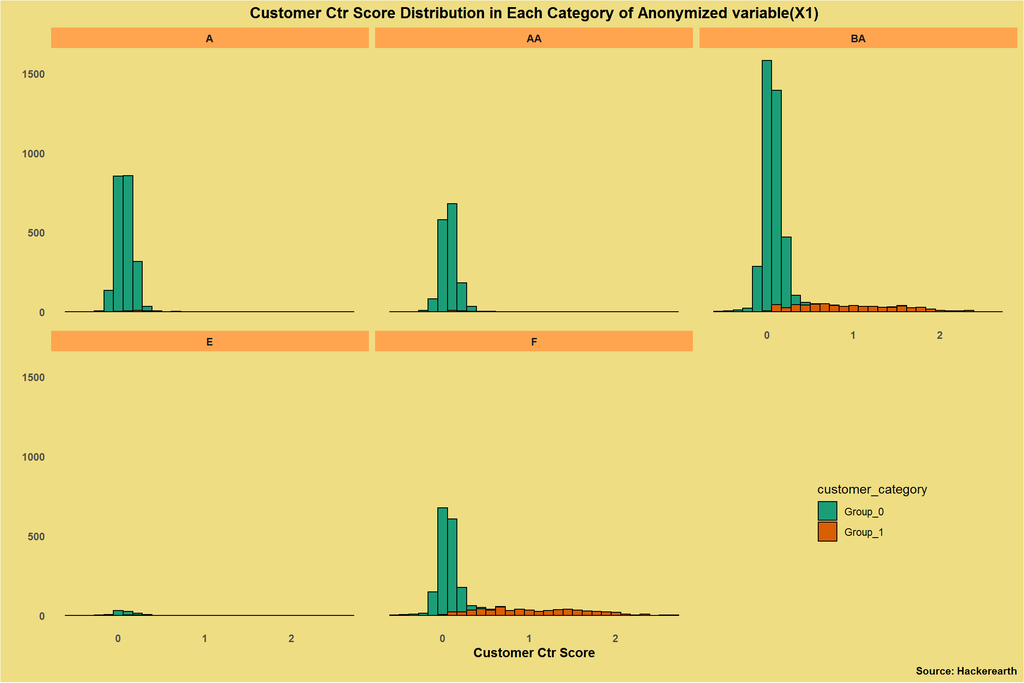

```r
train %>% mutate(customer_category =
                   recode(customer_category,
                          "0" = "Group_0",
                          "1" = "Group_1")) %>%
  na.omit() %>%
  ggplot(aes(x = customer_ctr_score,
             fill = customer_category)) +
  geom_histogram(color = "black"
  ) +
  scale_fill_brewer(palette = "Dark2")+
  facet_wrap( ~ X1)+
  labs(x="Customer Ctr Score",y="",caption = "Source: Hackerearth",
       title = "Customer Ctr Score Distribution in Each Category of Anonymized variable(X1)")+
  theme(
    axis.text = element_text(face = "bold"),
    axis.title.x =  element_text(face = "bold"),
    axis.ticks = element_blank(),
    legend.position = c(0.85,.20),
    panel.grid = element_blank(),
    strip.text = element_text(face = "bold"),
    strip.background.x = element_rect(fill = "tan1"),
    plot.caption = element_text(face = "bold"),
    plot.title = element_text(face = "bold",hjust = 0.5),
    plot.background = element_rect(fill = "lightgoldenrod"),
    panel.background = element_rect(fill = "transparent"),
    axis.line = element_blank(),
    legend.background = element_rect(fill = "transparent", colour = NA),
    legend.key = element_rect(fill = NA, color = NA)
  )
```

#### Let's check the customer ctr score by various categories of Anonymized variable(X1) and customer category.

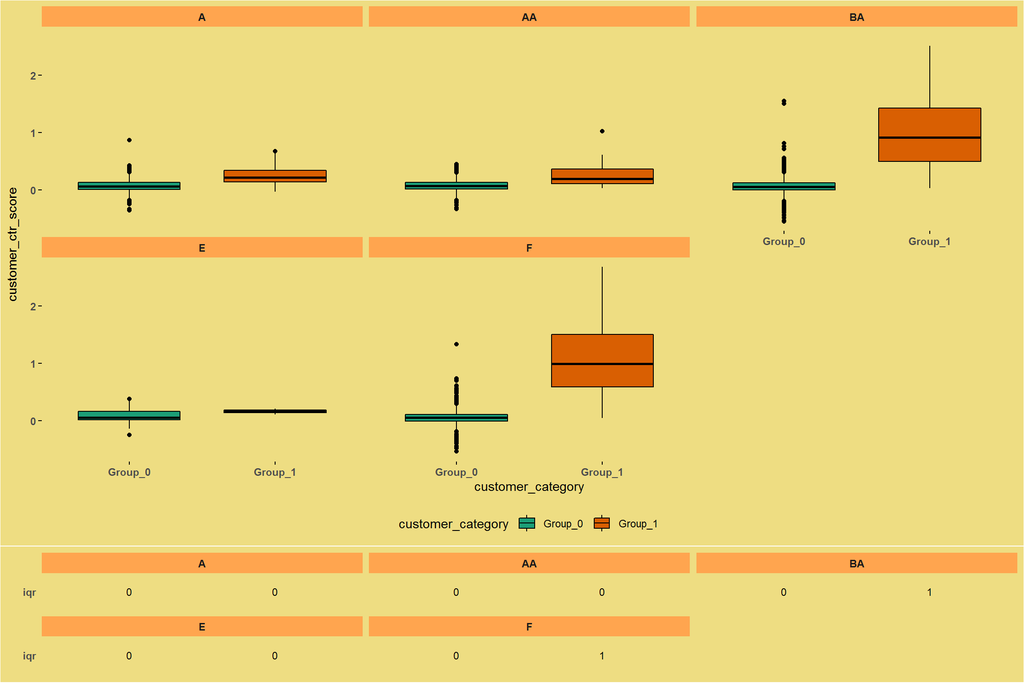

```r
ggsummarystats(
  train %>%
    mutate(customer_category =
             recode(customer_category,
                    "0" = "Group_0",
                    "1" = "Group_1")) %>%
    group_by(X1,
             customer_category) %>%
    select(X1,customer_category,
           customer_ctr_score) %>%
    drop_na(),
  x = "customer_category",
  y = "customer_ctr_score",
  ggfunc = ggboxplot,
  fill = "customer_category", palette = "Dark2",
  summaries = "iqr",
  labeller = "label_value",

  facet.by = "X1",
  ggtheme = theme(axis.text = element_text(face = "bold"),
                  #axis.title.x =  element_text(face = "bold"),
                  axis.ticks = element_blank(),
                  legend.position = c(0.85,.20),
                  panel.grid = element_blank(),
                  strip.text = element_text(face = "bold"),
                  strip.background.x = element_rect(fill = "tan1"),
                  plot.background = element_rect(fill = "lightgoldenrod"),
                  panel.background = element_rect(fill = "transparent"),
                  axis.line = element_blank(),
                  legend.background = element_rect(fill = "transparent", colour = NA),
                  legend.key = element_rect(fill = NA, color = NA)
  ) ,legend = "bottom"
)
```

#### The above chart shows that the group 0 customer category has more number outliers in all categories of the Anonymized variable(X1).

### Customer Frequency Score

#### Let's check the customer frequency score

#### customer frequency score, the score based on the number of times websites visited in a day by the customer.

#### Let's look quick summary of customer frequency score

```r
summary(train$customer_frequency_score)
```

```
##     Min.  1st Qu.   Median     Mean  3rd Qu.     Max.
##  0.02858  0.31361  0.51683  2.37689  1.12538 52.39501
```

#### summary shows no negative search score are there and the mean is 2.37689

#### binwidth selected by using Freedman–Diaconis rule.

```r
customer_frequency_scorebin<-hist(train$customer_frequency_score,breaks = "FD",plot = F)
```

```r
customer_frequency_score_his <- train %>%
  na.omit() %>%
  ggplot() +
  aes(x = customer_frequency_score) +
  geom_histogram(breaks = customer_frequency_scorebin$breaks,
                 color="red",
                 fill="lightcoral"

  ) +
  geom_vline(aes(xintercept = mean(customer_frequency_score)),
             col='blue',size=2)+

  theme_minimal() +
  labs(x = "",
       y = "",
       subtitle = "Histogram",
       title = "Customer Frequency Score Distribution"
  ) +
  theme_dark() +
  theme(
    axis.ticks = element_blank(),
    axis.title = element_text(face = "bold"),
    axis.text = element_text(face = "bold"),
    plot.title = element_text(hjust = 0.5, face = "bold"),
    plot.caption = element_text(face = "bold"),
    legend.background = element_rect(fill = "transparent", colour = NA),
    panel.grid = element_blank(),
    plot.background = element_rect(fill = "lightgoldenrod"),
    panel.background = element_rect(fill = "transparent")
  )






customer_frequency_score_box <- train %>%
  ggplot(aes(y="",x= customer_frequency_score,fill="lightcoral")) +
  geom_boxplot(varwidth=T,
               outlier.color  = "red",
               outlier.size = 2) +

   # stat_summary( geom="text", fun = box_summary ,
   #               size=4,vjust=1,
   #               #fun.args=list(probs=c(0,.5,.25,.75)),
   #              aes(
   #                 label=sprintf("%0.1f", ..x..))) +
  labs(x = "Customer Frequency Score",
       y = "",
       subtitle = "Box Plot",
       caption = "Source: Hackerearth",
       title = "") +
  theme_dark() +
  theme(
    axis.ticks = element_blank(),
    axis.title = element_text(face = "bold"),
    axis.text = element_text(face = "bold"),
    plot.title = element_text(hjust = 0.5, face = "bold"),
    plot.caption = element_text(face = "bold"),
    legend.position = "none",
    panel.grid = element_blank(),
    plot.background = element_rect(fill = "lightgoldenrod"),
    panel.background = element_rect(fill = "transparent")
  )

box_summary(train$customer_frequency_score)
```

```
## [1] 0.02857521 0.31360133 0.51682994 1.12543015 2.34263667
```

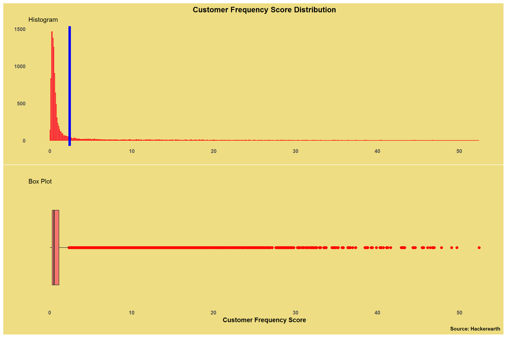

```r
customer_frequency_score_his/customer_frequency_score_box
```

#### The above histogram chart says that the customer frequency score is right-skewed(most of the customer frequency score falls below the mean).

#### The box plot explains there are outliers in the above upper limits.

#### Let's analyze the customer frequency score with more than one variable.

#### The following chart to analyze the customer frequency score by various customer_active_segment and customer category.

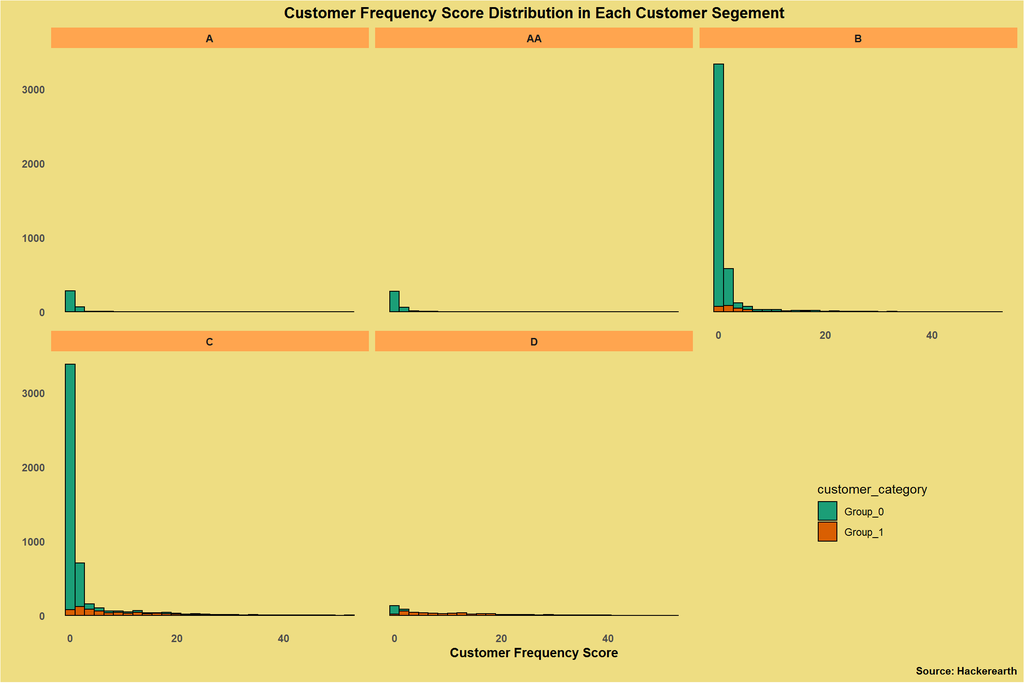

```r
train %>% mutate(customer_category =
                   recode(customer_category,
                          "0" = "Group_0",
                          "1" = "Group_1")) %>%
  na.omit() %>%
  ggplot(aes(x = customer_frequency_score,
             fill = customer_category)) +
  geom_histogram(color = "black"
  ) +
  scale_fill_brewer(palette = "Dark2")+
  facet_wrap( ~ customer_active_segment)+
  labs(x="Customer Frequency Score",y="",caption = "Source: Hackerearth",
       title = "Customer Frequency Score Distribution in Each Customer Segement")+
  theme(
    axis.text = element_text(face = "bold"),
    axis.title.x =  element_text(face = "bold"),
    axis.ticks = element_blank(),
    legend.position = c(0.85,.20),
    panel.grid = element_blank(),
    strip.text = element_text(face = "bold"),
    strip.background.x = element_rect(fill = "tan1"),
    plot.caption = element_text(face = "bold"),
    plot.title = element_text(face = "bold",hjust = 0.5),
    plot.background = element_rect(fill = "lightgoldenrod"),
    panel.background = element_rect(fill = "transparent"),
    axis.line = element_blank(),
    legend.background = element_rect(fill = "transparent", colour = NA),
    legend.key = element_rect(fill = NA, color = NA)
  )
```

#### The above chart shows that the customer frequency score range has different in each customer active segment. Customer category classification also shows a lot of differences.

#### In the next plot let's see any outlier points in customer frequency score by various customer active segment and Customer category.

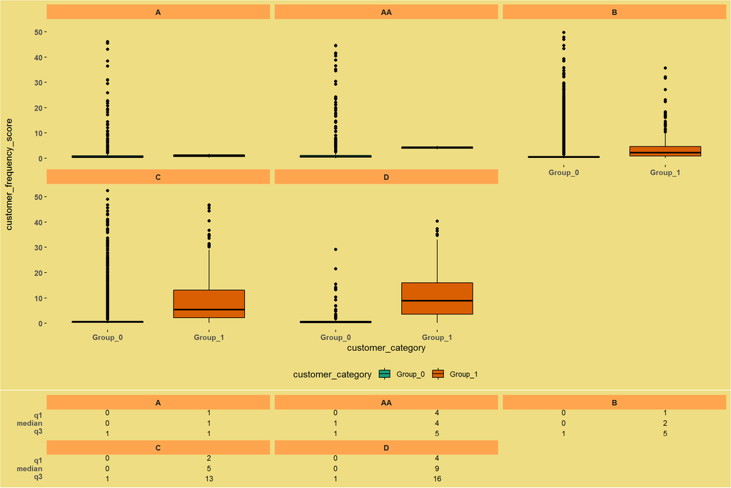

```r
ggsummarystats(
  train %>%
    mutate(customer_category =
             recode(customer_category,
                    "0" = "Group_0",
                    "1" = "Group_1")) %>%
    group_by(customer_active_segment,
             customer_category) %>%
    select(customer_active_segment,customer_category,
           customer_frequency_score) %>%
    drop_na(),
  x = "customer_category",
  y = "customer_frequency_score",
  ggfunc = ggboxplot,
  fill = "customer_category", palette = "Dark2",
  summaries = c("q1", "median","q3"),
  labeller = "label_value",
  facet.by = "customer_active_segment",
  ggtheme = theme(axis.text = element_text(face = "bold"),
                  #axis.title.x =  element_text(face = "bold"),
                  axis.ticks = element_blank(),
                  legend.position = c(0.85,.20),
                  panel.grid = element_blank(),
                  strip.text = element_text(face = "bold"),
                  strip.background.x = element_rect(fill = "tan1"),
                  plot.background = element_rect(fill = "lightgoldenrod"),
                  panel.background = element_rect(fill = "transparent"),
                  axis.line = element_blank(),
                  legend.background = element_rect(fill = "transparent", colour = NA),
                  legend.key = element_rect(fill = NA, color = NA)),
  legend = "bottom"
)
```

#### The above chart shows that the group 0 customer category has more number of outliers in all active Segments.

#### The following chart to analyze the customer frequency score by various category of Anonymized variable(X1) and customer category.

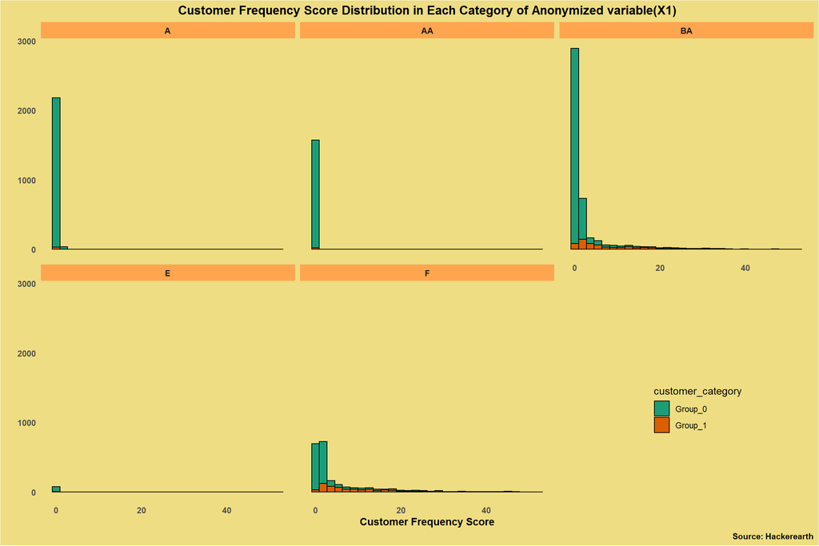

```r
train %>% mutate(customer_category =
                   recode(customer_category,
                          "0" = "Group_0",
                          "1" = "Group_1")) %>%
  na.omit() %>%
  ggplot(aes(x = customer_frequency_score,
             fill = customer_category)) +
  geom_histogram(color = "black"
  ) +
  scale_fill_brewer(palette = "Dark2")+
  facet_wrap( ~ X1)+
  labs(x="Customer Frequency Score",y="",caption = "Source: Hackerearth",
       title = "Customer Frequency Score Distribution in Each Category of Anonymized variable(X1)")+
  theme(
    axis.text = element_text(face = "bold"),
    axis.title.x =  element_text(face = "bold"),
    axis.ticks = element_blank(),
    legend.position = c(0.85,.20),
    panel.grid = element_blank(),
    strip.text = element_text(face = "bold"),
    strip.background.x = element_rect(fill = "tan1"),
    plot.caption = element_text(face = "bold"),
    plot.title = element_text(face = "bold",hjust = 0.5),
    plot.background = element_rect(fill = "lightgoldenrod"),
    panel.background = element_rect(fill = "transparent"),
    axis.line = element_blank(),
    legend.background = element_rect(fill = "transparent", colour = NA),
    legend.key = element_rect(fill = NA, color = NA)
  )
```

#### Let's check the customer frequency score by various categories of Anonymized variable(X1) and customer category.

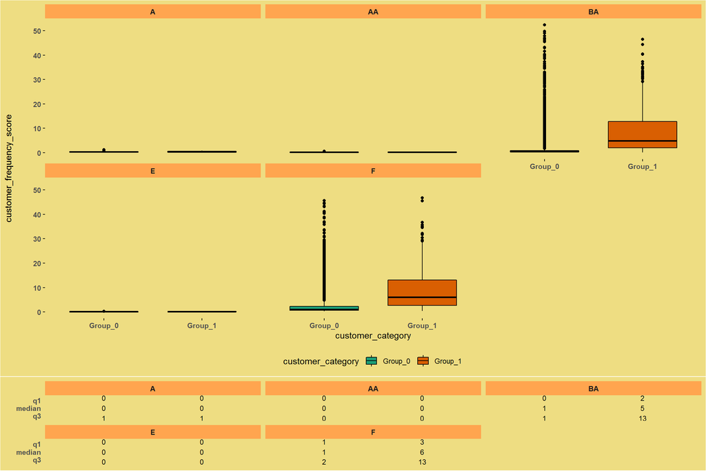

```r
ggsummarystats(
  train %>%
    mutate(customer_category =
             recode(customer_category,
                    "0" = "Group_0",
                    "1" = "Group_1")) %>%
    group_by(X1,
             customer_category) %>%
    select(X1,customer_category,
           customer_frequency_score) %>%
    drop_na(),
  x = "customer_category",
  y = "customer_frequency_score",
  ggfunc = ggboxplot,
  fill = "customer_category", palette = "Dark2",
  summaries = c("q1", "median","q3"),
  labeller = "label_value",

  facet.by = "X1",
  ggtheme = theme(axis.text = element_text(face = "bold"),
                  #axis.title.x =  element_text(face = "bold"),
                  axis.ticks = element_blank(),
                  legend.position = c(0.85,.20),
                  panel.grid = element_blank(),
                  strip.text = element_text(face = "bold"),
                  strip.background.x = element_rect(fill = "tan1"),
                  plot.background = element_rect(fill = "lightgoldenrod"),
                  panel.background = element_rect(fill = "transparent"),
                  axis.line = element_blank(),
                  legend.background = element_rect(fill = "transparent", colour = NA),
                  legend.key = element_rect(fill = NA, color = NA)
  ) ,legend = "bottom"
)
```

#### The above chart shows that both customer categories have more number of outliers in the BA and F categories of Anonymized variable(X1).

### Customer Product Variation Score

#### Let's check the customer product variation score

#### customer product variation score, the score based on varieties of products searched by the customer.

#### for example will search for tv , furnitures,..

#### Let's look quick summary of customer product variation score

```r
summary(train$customer_product_variation_score)
```

```
##    Min. 1st Qu.  Median    Mean 3rd Qu.    Max.    NA's
##   2.753   4.193   4.843   5.788   6.286  18.744      46
```

#### The summary shows no negative search score is there and the mean is 5.788.

#### binwidth selected by using Freedman–Diaconis rule.

```r
customer_product_variation_scorebin<-hist(train$customer_product_variation_score,breaks = "FD",plot = F)
```

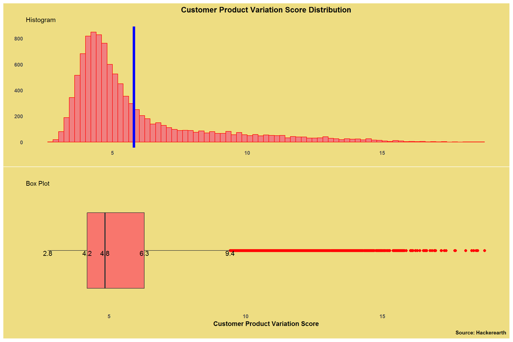

```r
customer_product_variation_score_his <- train %>%
  na.omit() %>%
  ggplot() +
  aes(x = customer_product_variation_score) +
  geom_histogram(breaks = customer_product_variation_scorebin$breaks,
                 color="red",
                 fill="lightcoral"

  ) +
  geom_vline(aes(xintercept = mean(customer_product_variation_score)),
             col='blue',size=2)+

  theme_minimal() +
  labs(x = "",
       y = "",
       subtitle = "Histogram",
       title = "Customer Product Variation Score Distribution"
  ) +
  theme_dark() +
  theme(
    axis.ticks = element_blank(),
    axis.title = element_text(face = "bold"),
    axis.text = element_text(face = "bold"),
    plot.title = element_text(hjust = 0.5, face = "bold"),
    plot.caption = element_text(face = "bold"),
    legend.background = element_rect(fill = "transparent", colour = NA),
    panel.grid = element_blank(),
    plot.background = element_rect(fill = "lightgoldenrod"),
    panel.background = element_rect(fill = "transparent")
  )






customer_product_variation_score_box <- train %>%
  ggplot(aes(y="",x= customer_product_variation_score,fill="lightcoral")) +
  geom_boxplot(varwidth=T,
               outlier.color  = "red",
               outlier.size = 2) +

  stat_summary( geom="text", fun = box_summary ,
                size=4,vjust=1,
                #fun.args=list(probs=c(0,.5,.25,.75)),
               aes(
                  label=sprintf("%0.1f", ..x..))) +
  labs(x = "Customer Product Variation Score",
       y = "",
       subtitle = "Box Plot",
       caption = "Source: Hackerearth",
       title = "") +
  theme_dark() +
  theme(
    axis.ticks = element_blank(),
    axis.title = element_text(face = "bold"),
    axis.text = element_text(face = "bold"),
    plot.title = element_text(hjust = 0.5, face = "bold"),
    plot.caption = element_text(face = "bold"),
    legend.position = "none",
    panel.grid = element_blank(),
    plot.background = element_rect(fill = "lightgoldenrod"),
    panel.background = element_rect(fill = "transparent")
  )


customer_product_variation_score_his/customer_product_variation_score_box
```

#### The above histogram chart says that the customer product variation score is right-skewed(most of the customer product variation score falls below the mean).

#### The boxplot explains there are outliers in the above upper limits.

#### Let's analyze the customer product variation score with more than one variable.

#### The following chart to analyze the customer product variation score by various customer_active_segment and customer category.

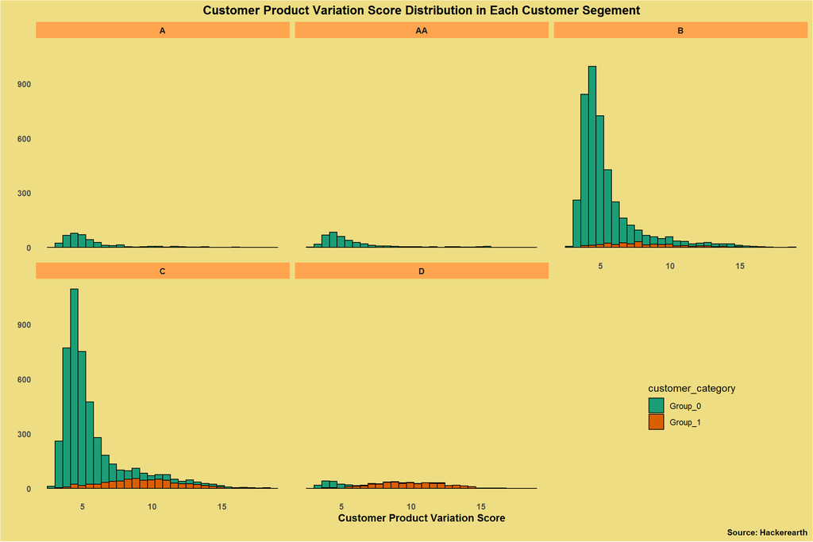

```r
train %>% mutate(customer_category =
                   recode(customer_category,
                          "0" = "Group_0",
                          "1" = "Group_1")) %>%
  na.omit() %>%
  ggplot(aes(x = customer_product_variation_score,
             fill = customer_category)) +
  geom_histogram(color = "black"
  ) +
  scale_fill_brewer(palette = "Dark2")+
  facet_wrap( ~ customer_active_segment)+
  labs(x="Customer Product Variation Score",y="",caption = "Source: Hackerearth",
       title = "Customer Product Variation Score Distribution in Each Customer Segement")+
  theme(
    axis.text = element_text(face = "bold"),
    axis.title.x =  element_text(face = "bold"),
    axis.ticks = element_blank(),
    legend.position = c(0.85,.20),
    panel.grid = element_blank(),
    strip.text = element_text(face = "bold"),
    strip.background.x = element_rect(fill = "tan1"),
    plot.caption = element_text(face = "bold"),
    plot.title = element_text(face = "bold",hjust = 0.5),
    plot.background = element_rect(fill = "lightgoldenrod"),
    panel.background = element_rect(fill = "transparent"),
    axis.line = element_blank(),
    legend.background = element_rect(fill = "transparent", colour = NA),
    legend.key = element_rect(fill = NA, color = NA)
  )
```

#### The above chart shows that the customer product variation Score range has different in each customer active segment. Customer category classification also shows a lot of differences.

#### In the next plot let's see any outlier points in customer product variation Score by various customer active segment and Customer category.

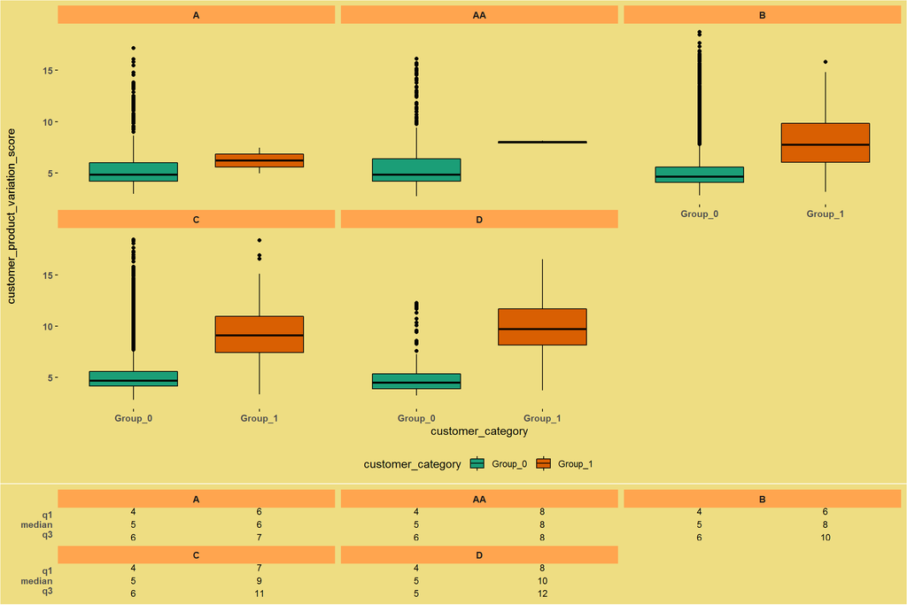

```r
ggsummarystats(
  train %>%
    mutate(customer_category =
             recode(customer_category,
                    "0" = "Group_0",
                    "1" = "Group_1")) %>%
    group_by(customer_active_segment,
             customer_category) %>%
    select(customer_active_segment,customer_category,
           customer_product_variation_score) %>%
    drop_na(),
  x = "customer_category",
  y = "customer_product_variation_score",
  ggfunc = ggboxplot,
  fill = "customer_category", palette = "Dark2",
  summaries = c("q1", "median","q3"),
  labeller = "label_value",
  facet.by = "customer_active_segment",
  ggtheme = theme(axis.text = element_text(face = "bold"),
                  #axis.title.x =  element_text(face = "bold"),
                  axis.ticks = element_blank(),
                  legend.position = c(0.85,.20),
                  panel.grid = element_blank(),
                  strip.text = element_text(face = "bold"),
                  strip.background.x = element_rect(fill = "tan1"),
                  plot.background = element_rect(fill = "lightgoldenrod"),
                  panel.background = element_rect(fill = "transparent"),
                  axis.line = element_blank(),
                  legend.background = element_rect(fill = "transparent", colour = NA),
                  legend.key = element_rect(fill = NA, color = NA)),
  legend = "bottom"
)
```

#### The above chart shows that the group 0 customer category has more number of outliers in all active Segments.